# 以下教程基于各官网教程

[Numpy教程](https://docs.scipy.org/doc/numpy/user/quickstart.html)  
[Matlab转Numpy](https://docs.scipy.org/doc/numpy/user/numpy-for-matlab-users.html)  
[matplotlib教程](https://matplotlib.org/tutorials/index.html)  
[pandas数据结构简介](https://pandas.pydata.org/pandas-docs/stable/getting_started/dsintro.html)  
[pandas十分钟教程](https://pandas.pydata.org/pandas-docs/stable/getting_started/10min.html)

# Numpy基本

## 基本概念

numpy的数组(ndarray)的维度称之为轴（axes），一维数组称之为有一个轴，二维数组有两个轴，以此类推，比如

```
[[1,2,3],
[4,5,6]]
```

有两个轴，第一个轴长度为2，第二个轴长度为3

以下为`numpy.ndarray`(别名`numpy.array`)中数组的基本属性:  
`ndarray.ndim`——数组轴数  
`ndarray.shape`——数组各轴的长度，返回的元组各元素表示数组各轴长度，元组长度即为数组轴数  
`ndarray.size`——数组中元素总个数  
`ndarray.dtype`——数组中元素类型  
`ndarray.itemsize`——数组中每个元素所占内存的大小  
`ndarray.data`——数组中保存的原始数据，通常不需要这种方式来访问数组数据

```python
import numpy as np
a=np.arange(15).reshape(3,5)
a
```

```
array([[ 0,  1,  2,  3,  4],
       [ 5,  6,  7,  8,  9],
       [10, 11, 12, 13, 14]])
```

```python
a.ndim
```

```
2
```

```python
a.shape
```

```
(3, 5)
```

```python
a.dtype.name
```

```
'int32'
```

```python
a.itemsize
```

```
4
```

```python
a.data
```

```
<memory at 0x0000020830C7E7E0>
```

## 数组创建

- 从序列(元组与列表)创建，自动由序列元素类型推断数组元素类型

```python
a=np.array([2,3,4,5])
a
```

```
array([2, 3, 4, 5])
```

```python
b=np.array([[1,2,3],[4,5,6]])
b
```

```
array([[1, 2, 3],
       [4, 5, 6]])
```

```python
c=np.array([(3,7,4),(2,5,9)])
c
```

```
array([[3, 7, 4],
       [2, 5, 9]])
```

```python
d=np.array(([2,7,3],[3,8,4]))
d
```

```
array([[2, 7, 3],
       [3, 8, 4]])
```

```python
e=np.array([(7,2,5),[4,1,0]])
e
```

```
array([[7, 2, 5],
       [4, 1, 0]])
```

可知，使用序列方式生成数组不在乎使用的是列表型还是元组型序列，甚至可以混用，但是最外面最好还是使用中括号，以免和`array`函数的括号搞混  
数组元素类型也可在生成的时候指定:

```python
f=np.array([[1,2,3,4,5],[6,7,8,9,0]],dtype=complex)
f
```

```
array([[1.+0.j, 2.+0.j, 3.+0.j, 4.+0.j, 5.+0.j],
       [6.+0.j, 7.+0.j, 8.+0.j, 9.+0.j, 0.+0.j]])
```

- 生成特殊数组（类似matlab生成特殊矩阵）

```python
a=np.zeros([3,4])#生成全为0数组
a
```

```
array([[0., 0., 0., 0.],
       [0., 0., 0., 0.],
       [0., 0., 0., 0.]])
```

```python
b=np.ones([5,5])#生成全为1数组
b
```

```
array([[1., 1., 1., 1., 1.],
       [1., 1., 1., 1., 1.],
       [1., 1., 1., 1., 1.],
       [1., 1., 1., 1., 1.],
       [1., 1., 1., 1., 1.]])
```

```python
c=np.empty([3,5])#生成未初始化数组,数组元素取决于内存所处的状态
c
```

```
array([[0., 0., 0., 0., 0.],
       [0., 0., 0., 0., 0.],
       [0., 0., 0., 0., 0.]])
```

```python
d=np.identity(4)#生成单位矩阵
d
```

```
array([[1., 0., 0., 0.],
       [0., 1., 0., 0.],
       [0., 0., 1., 0.],
       [0., 0., 0., 1.]])
```

```python
e=np.eye(4)
e
```

```
array([[1., 0., 0., 0.],
       [0., 1., 0., 0.],
       [0., 0., 1., 0.],
       [0., 0., 0., 1.]])
```

```python
np.linspace(1,10,10)
```

```
array([ 1.,  2.,  3.,  4.,  5.,  6.,  7.,  8.,  9., 10.])
```

```python
np.logspace(0,3,4)
```

```
array([   1.,   10.,  100., 1000.])
```

- 根据各轴坐标生成矩阵  
  使用`np.fromfunction(f,shape,**kwargs)`

```python
def f(x,y):
    return 10*x+y
```

```python
np.fromfunction(f,(5,4))
```

```
array([[ 0.,  1.,  2.,  3.],
       [10., 11., 12., 13.],
       [20., 21., 22., 23.],
       [30., 31., 32., 33.],
       [40., 41., 42., 43.]])
```

## 数组打印

横向为最后一个轴，竖向为倒数第二个轴，之后每添加一个轴都是往前添加  
最后一个轴由左向右打印  
倒数第二个轴由上到下打印  
其他轴由上到下打印

```python
a=np.arange(6)
print(a)
```

```
[0 1 2 3 4 5]
```

```python
b=np.arange(15).reshape(3,5)
print(b)
```

```
[[ 0  1  2  3  4]
 [ 5  6  7  8  9]
 [10 11 12 13 14]]
```

```python
c=np.arange(27).reshape(3,3,3)
print(c)
```

```
[[[ 0  1  2]
  [ 3  4  5]
  [ 6  7  8]]

 [[ 9 10 11]
  [12 13 14]
  [15 16 17]]

 [[18 19 20]
  [21 22 23]
  [24 25 26]]]
```

```python
print(np.arange(10000))
```

```
[   0    1    2 ... 9997 9998 9999]
```

```python
print(np.arange(10000).reshape(100,100))
```

```
[[   0    1    2 ...   97   98   99]
 [ 100  101  102 ...  197  198  199]
 [ 200  201  202 ...  297  298  299]
 ...
 [9700 9701 9702 ... 9797 9798 9799]
 [9800 9801 9802 ... 9897 9898 9899]
 [9900 9901 9902 ... 9997 9998 9999]]
```

关闭以上自动省略功能可以使用`np.set_printoptions(threshold=np.nan)`语句

## 基本运算

- 数组基本运算时按位运算

```python
import numpy as np
```

```python
a=np.array([20,30,40,50])
b=np.arange(4)
b
```

```
array([0, 1, 2, 3])
```

```python
a-b
```

```
array([20, 29, 38, 47])
```

```python
b**2
```

```
array([0, 1, 4, 9], dtype=int32)
```

```python
10*np.sin(a)
```

```
array([ 9.12945251, -9.88031624,  7.4511316 , -2.62374854])
```

- `*`运算也是按位运算,矩阵乘法使用`@`运算符

```python
A=np.array([(1,1),(0,1)])
B=np.array([(2,0),(3,4)])
A*B#按位乘法
```

```
array([[2, 0],
       [0, 4]])
```

```python
A@B#矩阵乘法
```

```
array([[5, 4],
       [3, 4]])
```

```python
A.dot(B)#矩阵乘法
```

```
array([[5, 4],
       [3, 4]])
```

- 增强赋值运算符

```python
A+=B
```

```python
A
```

```
array([[3, 1],
       [3, 5]])
```

```python
A+=3
```

```python
A
```

```
array([[6, 4],
       [6, 8]])
```

```python
B**=2
```

```python
B
```

```
array([[ 4,  0],
       [ 9, 16]])
```

按位运算时会自动向上转型，比如两个矩阵相加，结果元素的类型是两个相加数组的元素类型中更"泛"的那个类型

- 针对数组的单目运算符

```python
A.sum()
```

```
24
```

```python
A.max()
```

```
8
```

```python
A.min()
```

```
4
```

上述运算可以指定沿某个轴方向执行，比如沿二维数组的第一个轴求和就是按列求和

```python
A
```

```
array([[6, 4],
       [6, 8]])
```

```python
A.sum(axis=0)
```

```
array([12, 12])
```

```python
A.sum(axis=1)
```

```
array([10, 14])
```

```python
a=np.arange(12).reshape(3,4)
a
```

```
array([[ 0,  1,  2,  3],
       [ 4,  5,  6,  7],
       [ 8,  9, 10, 11]])
```

```python
a.max(axis=1)
```

```
array([ 3,  7, 11])
```

```python
a.cumsum(axis=0)
```

```
array([[ 0,  1,  2,  3],
       [ 4,  6,  8, 10],
       [12, 15, 18, 21]], dtype=int32)
```

```python
a.cumsum()
```

```
array([ 0,  1,  3,  6, 10, 15, 21, 28, 36, 45, 55, 66], dtype=int32)
```

## 通用函数

numpy提供`sin`,`cos`,`tan`等数学函数，对数组按位进行相应运算，称之为通用函数"universal function"(`ufunc`)

```python
a=np.arange(3)
a
```

```
array([0, 1, 2])
```

```python
np.exp(a)
```

```
array([1.        , 2.71828183, 7.3890561 ])
```

```python
np.sin(a)
```

```
array([0.        , 0.84147098, 0.90929743])
```

```python
np.sqrt(a)
```

```
array([0.        , 1.        , 1.41421356])
```

```python
np.add(a,np.power(a,2))
```

```
array([0, 2, 6])
```

## 索引、切片与迭代

- 一维数组与普通列表一样索引、切片与迭代

```python
a=np.arange(12)
```

```python
a[3]
```

```
3
```

```python
a[3:10]
```

```
array([3, 4, 5, 6, 7, 8, 9])
```

```python
a[::-1]
```

```
array([11, 10,  9,  8,  7,  6,  5,  4,  3,  2,  1,  0])
```

```python
a[1::3]
```

```
array([ 1,  4,  7, 10])
```

- 多维数组用多个索引，各个索引用逗号隔开，每个索引方式与一维数组是一样的

```python
b=np.fromfunction(lambda x,y:x**2+2*y,(5,4))
b
```

```
array([[ 0.,  2.,  4.,  6.],
       [ 1.,  3.,  5.,  7.],
       [ 4.,  6.,  8., 10.],
       [ 9., 11., 13., 15.],
       [16., 18., 20., 22.]])
```

```python
b[2,3]
```

```
10.0
```

```python
b[1:5,[1,2]]
```

```
array([[ 3.,  5.],
       [ 6.,  8.],
       [11., 13.],
       [18., 20.]])
```

```python
b[::-1,[3,1]]
```

```
array([[22., 18.],
       [15., 11.],
       [10.,  6.],
       [ 7.,  3.],
       [ 6.,  2.]])
```

```python
b[3]#第3行整行,缺失的索引自动补全为:
```

```
array([ 9., 11., 13., 15.])
```

```python
b[:,2]#第2列整列
```

```
array([ 4.,  5.,  8., 13., 20.])
```

```python
b[...,2]#...可以代表其他的轴全部用:索引,高阶的数组可以使用这种方式索引，指定首尾的索引，中间的可略
```

```
array([ 4.,  5.,  8., 13., 20.])
```

```python
for row in b:#按第一个轴迭代
    print(row)
```

```
[0. 2. 4. 6.]
[1. 3. 5. 7.]
[ 4.  6.  8. 10.]
[ 9. 11. 13. 15.]
[16. 18. 20. 22.]
```

```python
for all_ele in b.flat:#展开迭代
    print(all_ele)
```

```
0.0
2.0
4.0
6.0
1.0
3.0
5.0
7.0
4.0
6.0
8.0
10.0
9.0
11.0
13.0
15.0
16.0
18.0
20.0
22.0
```

## 变形

numpy中的ndarray有`shape`属性表示数组的形状（即沿每一个轴的元素个数），可使用以下几种方式生成改变形状的数组:

```python
a=np.floor(10*np.random.random([3,4]))
a
```

```
array([[6., 8., 8., 8.],
       [9., 6., 1., 1.],
       [0., 0., 4., 6.]])
```

```python
a.ravel()#展开
```

```
array([6., 8., 8., 8., 9., 6., 1., 1., 0., 0., 4., 6.])
```

> 展开是是使用C-Style，即后面的索引变化最快,a[0,0]之后是a[0,1]。numpy中横向(行)是最后一个轴方向,纵向(列)是倒数第二个轴方向,之后每添加一个轴都是往前面添加,比如四维数组a,a[2,1,5,3]中,5是倒数第二个轴方向索引,也即行号;3是最后一个轴索引,也即列号

```python
a.reshape(4,3)#变形
```

```
array([[6., 8., 8.],
       [8., 9., 6.],
       [1., 1., 0.],
       [0., 4., 6.]])
```

```python
a.T#转置
```

```
array([[6., 9., 0.],
       [8., 6., 0.],
       [8., 1., 4.],
       [8., 1., 6.]])
```

```python
a.resize(2,6)#原位变形
a
```

```
array([[6., 8., 8., 8., 9., 6.],
       [1., 1., 0., 0., 4., 6.]])
```

```python
a.reshape(3,-1)#-1表示自动推测沿第二轴元素个数
```

```
array([[6., 8., 8., 8.],
       [9., 6., 1., 1.],
       [0., 0., 4., 6.]])
```

## 数组堆叠拼接

```python
a=np.floor(10*np.random.random([3,3]))
print('a=')
print(a)
b=np.floor(10*np.random.random([3,3]))
print('b=')
print(b)
```

```
a=
[[8. 6. 4.]
 [0. 6. 5.]
 [6. 7. 9.]]
b=
[[9. 2. 2.]
 [3. 2. 5.]
 [9. 9. 1.]]
```

- `hstack`与`vsatck`函数分别进行水平堆叠与垂直堆叠
- `column_stack`与`row_stack`分别进行当做列堆叠与当做行堆叠，对二维数组堆叠时分别与`hstack`，`vstack`功能相同

```python
np.hstack([a,b])
```

```
array([[8., 6., 4., 9., 2., 2.],
       [0., 6., 5., 3., 2., 5.],
       [6., 7., 9., 9., 9., 1.]])
```

```python
np.vstack((a,b))
```

```
array([[8., 6., 4.],
       [0., 6., 5.],
       [6., 7., 9.],
       [9., 2., 2.],
       [3., 2., 5.],
       [9., 9., 1.]])
```

```python
np.column_stack([a,b])
```

```
array([[8., 6., 4., 9., 2., 2.],
       [0., 6., 5., 3., 2., 5.],
       [6., 7., 9., 9., 9., 1.]])
```

```python
np.row_stack([a,b])
```

```
array([[8., 6., 4.],
       [0., 6., 5.],
       [6., 7., 9.],
       [9., 2., 2.],
       [3., 2., 5.],
       [9., 9., 1.]])
```

一维数组堆叠时使用`column_stack`与`hstack`效果不一样，因为`column_stack`将一维数组当成列向量横向堆叠,但是`hstack`将一维数组当做行向量堆叠

```python
c=np.arange(3)
d=np.arange(3,6)
```

```python
np.column_stack([c,d])
```

```
array([[0, 3],
       [1, 4],
       [2, 5]])
```

```python
np.hstack([c,d])
```

```
array([0, 1, 2, 3, 4, 5])
```

```python
np.row_stack([c,d])
```

```
array([[0, 1, 2],
       [3, 4, 5]])
```

```python
np.vstack([c,d])
```

```
array([[0, 1, 2],
       [3, 4, 5]])
```

加入一个新的第二个轴则可以把一维数组变成二维数组，这时候用`hstack`效果与`column_stack`一样了

```python
from numpy import newaxis
c[:,newaxis]
```

```
array([[0],
       [1],
       [2]])
```

```python
np.hstack([c[:,newaxis],d[:,newaxis]])
```

```
array([[0, 3],
       [1, 4],
       [2, 5]])
```

```python
c[:,newaxis].shape
```

```
(3, 1)
```

```python
c[newaxis,:]
```

```
array([[0, 1, 2]])
```

```python
c[newaxis,:].shape
```

```
(1, 3)
```

`concatenate`函数可以直接指定沿哪个轴进行堆叠

```python
np.concatenate([a,b],axis=1)
```

```
array([[8., 6., 4., 9., 2., 2.],
       [0., 6., 5., 3., 2., 5.],
       [6., 7., 9., 9., 9., 1.]])
```

`r_`与`c_`函数可以直接生成水平、垂直堆叠而成的数组，不一样的是，函数里可以使用`:`字符快速生成范围数组

```python
np.r_[0:4,9,16]
```

```
array([ 0,  1,  2,  3,  9, 16])
```

```python
np.c_[2:5,3:6,4:7]
```

```
array([[2, 3, 4],
       [3, 4, 5],
       [4, 5, 6]])
```

## 数组分割

类似数组堆叠，数组可以水平、垂直分割

```python
a=np.floor(10*np.random.random([2,12]))
a
```

```
array([[6., 9., 4., 9., 5., 0., 3., 1., 1., 9., 6., 9.],
       [5., 9., 1., 9., 9., 1., 9., 3., 1., 8., 7., 0.]])
```

```python
np.hsplit(a,3)#均分
```

```
[array([[6., 9., 4., 9.],
        [5., 9., 1., 9.]]), array([[5., 0., 3., 1.],
        [9., 1., 9., 3.]]), array([[1., 9., 6., 9.],
        [1., 8., 7., 0.]])]
```

```python
np.hsplit(a,[5,7])#给出元组按列号分
```

```
[array([[6., 9., 4., 9., 5.],
        [5., 9., 1., 9., 9.]]), array([[0., 3.],
        [1., 9.]]), array([[1., 1., 9., 6., 9.],
        [3., 1., 8., 7., 0.]])]
```

```python
b=np.floor(10*np.random.random([8,3]))
b
```

```
array([[3., 4., 3.],
       [4., 6., 9.],
       [5., 1., 6.],
       [5., 1., 7.],
       [5., 9., 5.],
       [7., 7., 1.],
       [2., 5., 7.],
       [9., 1., 5.]])
```

```python
np.vsplit(b,2)
```

```
[array([[3., 4., 3.],
        [4., 6., 9.],
        [5., 1., 6.],
        [5., 1., 7.]]), array([[5., 9., 5.],
        [7., 7., 1.],
        [2., 5., 7.],
        [9., 1., 5.]])]
```

```python
np.vsplit(b,[2,3,4])
```

```
[array([[3., 4., 3.],
        [4., 6., 9.]]),
 array([[5., 1., 6.]]),
 array([[5., 1., 7.]]),
 array([[5., 9., 5.],
        [7., 7., 1.],
        [2., 5., 7.],
        [9., 1., 5.]])]
```

`array_split`可以指定沿哪个轴分割

```python
np.array_split(a,2,axis=1)
```

```
[array([[6., 9., 4., 9., 5., 0.],
        [5., 9., 1., 9., 9., 1.]]), array([[3., 1., 1., 9., 6., 9.],
        [9., 3., 1., 8., 7., 0.]])]
```

## 拷贝与视图

- 无拷贝——简单赋值号无拷贝，即是同一个对象，引用传递

```python
a=np.arange(12).reshape([3,4])
a
```

```
array([[ 0,  1,  2,  3],
       [ 4,  5,  6,  7],
       [ 8,  9, 10, 11]])
```

```python
b=a
b is a
```

```
True
```

```python
b.shape=4,3
a.shape
```

```
(4, 3)
```

- 视图与浅拷贝——切片所得的是浅拷贝视图（即视图可以不一样，但是数据是一样的）

```python
c=a.view()
c is a
```

```
False
```

```python
c.base is a.base
```

```
True
```

```python
c.shape=2,6
a.shape
```

```
(4, 3)
```

```python
c[0,4]=1234
a
```

```
array([[   0,    1,    2],
       [   3, 1234,    5],
       [   6,    7,    8],
       [   9,   10,   11]])
```

```python
s=a[:,1:3]
s[:]=10
a
```

```
array([[ 0, 10, 10],
       [ 3, 10, 10],
       [ 6, 10, 10],
       [ 9, 10, 10]])
```

- 深拷贝

```python
c=a.copy()
c is a
```

```
False
```

```python
c.base is a.base
```

```
False
```

```python
c[0,0]=9999
c
```

```
array([[9999,   10,   10],
       [   3,   10,   10],
       [   6,   10,   10],
       [   9,   10,   10]])
```

```python
a
```

```
array([[ 0, 10, 10],
       [ 3, 10, 10],
       [ 6, 10, 10],
       [ 9, 10, 10]])
```

## 函数与方法一览

函数与方法一览，参见[官网tutorial](https://docs.scipy.org/doc/numpy/user/quickstart.html#functions-and-methods-overview)

- 数组创建:  
  `arange`,`array`,`copy`,`empty`,`empty_like`,`eye`,`fromfile`,`fromfunction`,`identity`,  
  `linspace`,`logspace`,`mgrid`,`ogrid`,`ones`,`ones_like`,`r`,`zeros`,`zeros_like`
- 数组转换  
  `ndarray.astype`,`atleast_1d`,`atleast_2d`,`atleast_3d`,`mat`
- 数组操作  
  `array_split`,`column_stack`,`concatenate`,`diagonal`,`dsplit`,`dstack`,`hsplit`,`hstack`,  
  `ndarray.item`,`newaxis`,`ravel`,`repeat`,`reshape`,`resize`,`squeeze`,`swapaxes`,`take`,`transpose`,`vsplit`,`vstack`
- 问题  
  `all`, `any`, `nonzero`, `where`
- 排序  
  `argmax`, `argmin`, `argsort`, `max`, `min`, `ptp`, `searchsorted`, `sort`
- 运算  
  `choose`, `compress`, `cumprod`, `cumsum`, `inner`, `ndarray.fill`, `imag`, `prod`, `put`, `putmask`, `real`, `sum`
- 基本统计  
  `cov`, `mean`, `std`, `var`
- 基本线性代数  
  `cross`, `dot`, `outer`, `linalg.svd`, `vdot`

# Numpy进阶

## 广播法则

针对不同维，不同尺寸的数组之间进行按位运算会自动执行广播法则，广播法则如下：

- 低阶数组与高阶数组按位运算时会自动升维成为同阶数组，增加的维度尺寸自动设为1
- 某个维度上尺寸为1的数组与该维度上尺度不为1的数组按位运算时会自动上升到同一尺寸，沿该维度增加的元素与第一个元素相同

```python
from numpy import newaxis
a=np.arange(12).reshape(3,4)
b=np.arange(4)
c=np.arange(1,4)[:,newaxis]
print(a)
print()
print(b)
print()
print(c)
```

```
[[ 0  1  2  3]
 [ 4  5  6  7]
 [ 8  9 10 11]]

[0 1 2 3]

[[1]
 [2]
 [3]]
```

```python
a+b
```

```
array([[ 0,  2,  4,  6],
       [ 4,  6,  8, 10],
       [ 8, 10, 12, 14]])
```

`a`与`b`不同阶(`b`是一阶数组,`a`是二阶数组),`b`自动升维成2阶数组,但是在第二个轴上与`a`尺寸不同,故自动增加相同的元素,最后成为  
array([[0,1,2,3],[0,1,2,3],[0,1,2,3]])  
然后`a+b`成为同阶同尺寸的按位运算

```python
a**c
```

```
array([[   0,    1,    2,    3],
       [  16,   25,   36,   49],
       [ 512,  729, 1000, 1331]], dtype=int32)
```

```python
b*c
```

```
array([[0, 1, 2, 3],
       [0, 2, 4, 6],
       [0, 3, 6, 9]])
```

```python
c+1
```

```
array([[2],
       [3],
       [4]])
```

## 高级索引技巧

### 数组索引

数组索引即为用数组做索引。对高维数组进行索引，每个维度都要使用一个数组，且因为作为索引的数组决定切片的shape，所以所有的数组必须形状(shape)相同

```python
a=np.arange(20).reshape(4,5)
a
```

```
array([[ 0,  1,  2,  3,  4],
       [ 5,  6,  7,  8,  9],
       [10, 11, 12, 13, 14],
       [15, 16, 17, 18, 19]])
```

```python
b=np.arange(8)
b
```

```
array([0, 1, 2, 3, 4, 5, 6, 7])
```

```python
c=np.array([2,3,2,5,0,1])
b[c]
```

```
array([2, 3, 2, 5, 0, 1])
```

```python
d=np.array([[1,2],[1,2]])#d,e必须shape相同，因为他们的shape决定返回数组的shape；d,e分别决定第一维与第二维的索引
e=np.array([[3,0],[2,1]])
a[d,e]
```

```
array([[ 8, 10],
       [ 7, 11]])
```

也可以使用一个序列把d,e装起来然后对a索引；但是注意不能把d,e装起来变成数组(array)对a索引，因为数组对a索引会把该数组作为第一个维度的索引

```python
l=d,e
a[l]
```

```
array([[ 8, 10],
       [ 7, 11]])
```

```python
l=np.array([d,e])
a[l]
```

```
array([[[[ 5,  6,  7,  8,  9],
         [10, 11, 12, 13, 14]],

        [[ 5,  6,  7,  8,  9],
         [10, 11, 12, 13, 14]]],


       [[[15, 16, 17, 18, 19],
         [ 0,  1,  2,  3,  4]],

        [[10, 11, 12, 13, 14],
         [ 5,  6,  7,  8,  9]]]])
```

当然可以像以下使用两个序列来进行切片，但这样相对来说受限——结果数组中同一行必定来自源数组同一行，同一列必定来自源数组同一列——相对来说，数组索引可以不受此限制，比如要生成一个2*2数组，比如上面的`a[d,e]`，就无法使用序列索引切片达到

```python
a[[1,3,2],1:]
```

```
array([[ 6,  7,  8,  9],
       [16, 17, 18, 19],
       [11, 12, 13, 14]])
```

数组索引切片作为左值(与普通切片一样，只是一个视图，是浅拷贝)

```python
import numpy as np
a=np.arange(12).reshape(3,4)
a
```

```
array([[ 0,  1,  2,  3],
       [ 4,  5,  6,  7],
       [ 8,  9, 10, 11]])
```

```python
a[1]=0
a
```

```
array([[ 0,  1,  2,  3],
       [ 0,  0,  0,  0],
       [ 8,  9, 10, 11]])
```

```python
ix=np.array([[0,2],[0,2]])
iy=np.array([[1,1],[2,2]])
a[ix,iy]=99
a
```

```
array([[ 0, 99, 99,  3],
       [ 0,  0,  0,  0],
       [ 8, 99, 99, 11]])
```

### 布尔值索引

布尔值索引有两种方式，

- 一种是给出一个与源数组同形状的逻辑数组，指定每一个元素是否需要
- 一种是对每一个维度给出一个逻辑数组，会自动转换成对应的数组索引进行索引

```python
a=np.floor(10*np.random.random([4,5]))
a
```

```
array([[2., 8., 4., 5., 7.],
       [6., 0., 7., 0., 9.],
       [2., 1., 5., 9., 5.],
       [8., 5., 2., 9., 4.]])
```

```python
b=a>=5
b
```

```
array([[False,  True, False,  True,  True],
       [ True, False,  True, False,  True],
       [False, False,  True,  True,  True],
       [ True,  True, False,  True, False]])
```

```python
a[b]
```

```
array([8., 5., 7., 6., 7., 9., 5., 9., 5., 8., 5., 9.])
```

```python
c=np.arange(a.shape[0])%2==0
c
```

```
array([ True, False,  True, False])
```

```python
d=np.arange(a.shape[1])
d=(d==0)|(d==2)
d
```

```
array([ True, False,  True, False, False])
```

> 要注意运算符的优先级,`==`比位运算符要低,参考[Python运算符优先级](http://www.runoob.com/python/python-operators.html#ysf8)

```python
a[c]
```

```
array([[2., 8., 4., 5., 7.],
       [2., 1., 5., 9., 5.]])
```

```python
a[:,d]
```

```
array([[2., 4.],
       [6., 7.],
       [2., 5.],
       [8., 2.]])
```

```python
a[c,d]
```

```
array([2., 5.])
```

> 这里比较奇怪，按照我原来的意思，应当是取出偶数行，0、2列交叉处的元素,但事实出乎意料。就我的理解，
> - 布尔值作索引其实是转化成对应的数组索引，只是把True对应位置的索引保留组成数组来索引,所以`a[c]`等价于`a[[0,2]]`
> - 而各个维度都是索引时可能会自动转型成各个维度都是ndarray，由上面可知,各个维度给出数组索引时,每个索引必须shape相同,且其shape就是最后结果的shape。所以上述`a[c,d]`其实等价于`a[[0,2],[0,2]]`,而两个维度上的序列`[0,2]`索引又被转型成两个`array([0,2])`,成了`a[array([0,2]),array([0,2])]`,最后索引的结果是一个shape为(2,)的数组,两个元素分别为`a[0,0]`与`a[2,2]`。假设改为`a[[0,2],[0,2,4]]`则不可以，因为序列转化成ndarray后不是合法的数组索引(两个索引shape不合)

```python
a[[True,False,True,False],[True,False,True,False,True]]
```

```
---------------------------------------------------------------------------
IndexError                                Traceback (most recent call last)
<ipython-input-57-9582139dcec8> in <module>()
----> 1 a[[True,False,True,False],[True,False,True,False,True]]

IndexError: shape mismatch: indexing arrays could not be broadcast together with shapes (2,) (3,)
```

而如果要取某几行某几列应该怎么做？相对于matlab中一步到位，python中需要两步才行,比如上述要取a的1,3行,1,3列子集如上`a[c,d]`是错误的,正确的应该如下:

```python
a[c][:,d]
```

```
array([[2., 4.],
       [2., 5.]])
```

## numpy.ix_()函数

numpy中的`ix_()`函数充分利用了广播的特性,用于生成坐标网格。我们知道在matlab中将两个向量生成网格可以用`meshgrid`函数，比如:

```
>>>x=1:5
x=
    1  2  3  4  5
>>>y=6:10
y=
    6  7  8  9  10
>>>[X,Y]=meshgrid(x,y)
X=
    1  2  3  4  5
    1  2  3  4  5
    1  2  3  4  5
    1  2  3  4  5
    1  2  3  4  5
Y=
    6  6  6  6  6
    7  7  7  7  7
    8  8  8  8  8
    9  9  9  9  9
    10 10 10 10 10
>>>Z=X.*Y
Z=
    6  12 18 24 30
    7  14 21 28 35
    8  16 24 32 40
    9  18 27 36 45
    10 20 30 40 50
```

但是这样生成的X,Y矩阵有大量的冗余数据,numpy的`ix_()`函数则不是；`ix_()`函数返回向量，但是是在不同维度上的向量，这样进行按位运算时会利用到广播的特性，起到与网格同样的效果,且不增加数据量:

```python
a=np.arange(1,6)
b=np.arange(6,11)
ax,bx=np.ix_(a,b)
ax,bx
```

```
(array([[1],
        [2],
        [3],
        [4],
        [5]]), array([[ 6,  7,  8,  9, 10]]))
```

```python
ax.shape,bx.shape
```

```
((5, 1), (1, 5))
```

```python
c=ax*bx
c
```

```
array([[ 6,  7,  8,  9, 10],
       [12, 14, 16, 18, 20],
       [18, 21, 24, 27, 30],
       [24, 28, 32, 36, 40],
       [30, 35, 40, 45, 50]])
```

```python
c[2,3]
```

```
27
```

```python
a[2]*b[3]
```

```
27
```

numpy中还有`ogrid`与`mgrid`方法生成坐标网格，差别是`ogrid`和`ix_()`函数一样，生成不同维度上的向量，而`mgrid`像matlab一样生成密集网格;`ogrid`与`mgrid`可以使用范围数组类似的生成方法:

```python
np.ogrid[-1:1:0.5]
```

```
array([-1. , -0.5,  0. ,  0.5])
```

```python
np.mgrid[-1:1:0.5]
```

```
array([-1. , -0.5,  0. ,  0.5])
```

```python
ao,bo=np.ogrid[0:3:0.5,4:7:0.5]
ao,bo
```

```
(array([[0. ],
        [0.5],
        [1. ],
        [1.5],
        [2. ],
        [2.5]]), array([[4. , 4.5, 5. , 5.5, 6. , 6.5]]))
```

```python
ao.shape,bo.shape
```

```
((6, 1), (1, 6))
```

```python
am,bm=np.mgrid[0:3:0.5,4:7:0.5]
am,bm
```

```
(array([[0. , 0. , 0. , 0. , 0. , 0. ],
        [0.5, 0.5, 0.5, 0.5, 0.5, 0.5],
        [1. , 1. , 1. , 1. , 1. , 1. ],
        [1.5, 1.5, 1.5, 1.5, 1.5, 1.5],
        [2. , 2. , 2. , 2. , 2. , 2. ],
        [2.5, 2.5, 2.5, 2.5, 2.5, 2.5]]),
 array([[4. , 4.5, 5. , 5.5, 6. , 6.5],
        [4. , 4.5, 5. , 5.5, 6. , 6.5],
        [4. , 4.5, 5. , 5.5, 6. , 6.5],
        [4. , 4.5, 5. , 5.5, 6. , 6.5],
        [4. , 4.5, 5. , 5.5, 6. , 6.5],
        [4. , 4.5, 5. , 5.5, 6. , 6.5]]))
```

```python
am.shape,bm.shape
```

```
((6, 6), (6, 6))
```

如果第二个`:`后是实数，则表示步进值，且不包括终止值(与范围数组生成方法一样)；如果第二个`:`后是虚数，则表示生成数的个数，包括终止值(与`np.linspace`函数一致):

```python
ao,bo=np.ogrid[0:4:5j,6:10:5j]
ao,bo
```

```
(array([[0.],
        [1.],
        [2.],
        [3.],
        [4.]]), array([[ 6.,  7.,  8.,  9., 10.]]))
```

```python
am,bm=np.mgrid[0:4:5j,6:10:5j]
am,bm
```

```
(array([[0., 0., 0., 0., 0.],
        [1., 1., 1., 1., 1.],
        [2., 2., 2., 2., 2.],
        [3., 3., 3., 3., 3.],
        [4., 4., 4., 4., 4.]]), array([[ 6.,  7.,  8.,  9., 10.],
        [ 6.,  7.,  8.,  9., 10.],
        [ 6.,  7.,  8.,  9., 10.],
        [ 6.,  7.,  8.,  9., 10.],
        [ 6.,  7.,  8.,  9., 10.]]))
```

## 线性代数

### 基本操作

```python
a=np.array([[1.0,2.0],[3.0,4.0]])
print(a)
```

```
[[1. 2.]
 [3. 4.]]
```

- 转置

```python
a.transpose()
```

```
array([[1., 3.],
       [2., 4.]])
```

- 求逆

```python
b=np.linalg.inv(a)
b
```

```
array([[-2. ,  1. ],
       [ 1.5, -0.5]])
```

- 矩阵乘法

```python
a@b,b@a
```

```
(array([[1.00000000e+00, 1.11022302e-16],
        [0.00000000e+00, 1.00000000e+00]]),
 array([[1.0000000e+00, 4.4408921e-16],
        [0.0000000e+00, 1.0000000e+00]]))
```

- 求迹

```python
u=np.eye(5)#单位矩阵
u
```

```
array([[1., 0., 0., 0., 0.],
       [0., 1., 0., 0., 0.],
       [0., 0., 1., 0., 0.],
       [0., 0., 0., 1., 0.],
       [0., 0., 0., 0., 1.]])
```

```python
np.trace(u)
```

```
5.0
```

- 求解线性方程组

```python
y=np.array([5,7])[:,newaxis]
y
```

```
array([[5],
       [7]])
```

```python
x=np.linalg.solve(a,y)#求线性方程组
x
```

```
array([[-3.],
       [ 4.]])
```

```python
a@x==y
```

```
array([[ True],
       [ True]])
```

- 求特征值、特征向量

```python
j=np.array([[3.0,2.0,1.0],[2.0,2.0,4.0],[1.0,4.0,1.0]])
w,v=np.linalg.eig(j)
w,v
```

```
(array([ 6.77881035,  1.81790737, -2.59671773]),
 array([[ 0.49974338,  0.85870632,  0.1134901 ],
        [ 0.66932902, -0.29967981, -0.67984607],
        [ 0.54977742, -0.41571079,  0.72452006]]))
```

```python
np.diag(w)
```

```
array([[ 6.77881035,  0.        ,  0.        ],
       [ 0.        ,  1.81790737,  0.        ],
       [ 0.        ,  0.        , -2.59671773]])
```

```python
v.T@j@v
```

```
array([[ 6.77881035e+00, -1.52280308e-15, -9.55816643e-18],
       [-1.42546771e-15,  1.81790737e+00, -1.85604399e-16],
       [-1.28994776e-16, -3.67237796e-16, -2.59671773e+00]])
```

### 技巧与建议

- 自动重构(reshape)

```python
a=np.arange(30)
a.shape=2,-1,3
a.shape
```

```
(2, 5, 3)
```

> -1表示自动推断大小
- 向量堆叠

```python
x=np.arange(5)
y=x*2
x,y
```

```
(array([0, 1, 2, 3, 4]), array([0, 2, 4, 6, 8]))
```

```python
np.vstack([x,y])
```

```
array([[0, 1, 2, 3, 4],
       [0, 2, 4, 6, 8]])
```

```python
np.hstack([x,y])
```

```
array([0, 1, 2, 3, 4, 0, 2, 4, 6, 8])
```

- 直方图

matplotlib中的`hist`会直接画出直方图,但是numpy里的`histogram`只是生成数据

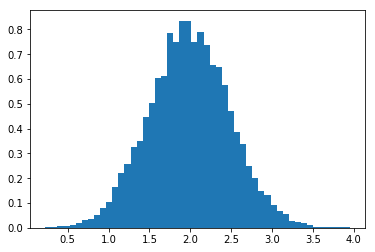

```python
import numpy as np
import matplotlib.pyplot as plt
mu,sigma=2,0.5
v=np.random.normal(mu,sigma,10000)
plt.hist(v,bins=50,density=1)
plt.show()
```

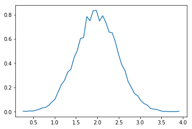

```python
[n,bins]=np.histogram(v,bins=50,density=True)
plt.plot(0.5*(bins[:-1]+bins[1:]),n)
plt.show()
```

> `np.histogram`返回各个直方条的高度n及直方条的左右边缘值bins，因为一个直方条有两个边缘，最后bins会比n多一个；因为`density=True`所以n被标准化了（即积分为1,不再表示每个条的频数,而是频率密度）

# Matlab到Numpy比较

## 关键差别

| matlab | Numpy |
| --- | --- |
| matlab中的基本数据类型是双精度浮点数组成的多维数组,其中二维数组的运算或多或少类似线性代数中的矩阵运算 | Numpy中基本数据类型是多维数组`array`，其操作大多是按位操作，线性代数运算需要特殊的函数实现 |
| matlab索引从1开始 | numpy索引从0开始 |
| matlab是特地为线性代数设计的，矩阵运算非常优雅与简洁，相对来说GUI方面和做成熟的应用方面有欠考虑 | python出发点是作为一个通用编程语言，numpy作为其补充，可以做到许多matlab无法做的事情 |
| matlab数组赋值、切片等使用值传递 | numpy数组使用引用传递，切片只是生成一个视图，属于浅拷贝 |

## 该使用数组还是矩阵

出于历史原因，numpy中也有一个`matrix`类,那么到底该使用数组还是矩阵?  
长期上来说`matrix`类将逐渐被弃用,所以当然是选用数组,二者比较如下:

- `*`与`@`运算符的区别,`dot()`函数与`multiply()`函数的区别。
  - 对`array`来说,`*`与`multiply()`是按位乘法,而`@`与`dot()`是矩阵乘法
  - 对`matrix`来说,`*`意味着矩阵乘法,而按位乘法必须用`multiply()`
- 处理向量（一维数组）方式上
  - 对`array`来说,(Nx1)数组、(1xN)数组和(N,)数组是完全不一样的概念,前两个是二维数组，而最后一个是一维数组;`array`中类似A[:,1]的操作返回的是大小为N的一维数组而不是Nx1的二维数组,一维数组既可以当做行向量也可以当做列向量，A@v时v自动看做列向量,v@A时v自动看做行向量;转置一维数组没有意义
  - 对`matrix`来说，一维数组总是向上转为1xN或者Nx1的二维数组（行列向量）
- 处理高维数组上。
  - `array`可以有2维以上的数组
  - `matrix`只能有2为数组（即使一维数组也会向上转为二维数组）

```python
A=np.array([[1,2],[3,4]])
v=np.array([4,5])
A@v,v@A
```

```
(array([14, 32]), array([19, 28]))
```

## Matlab与Numpy等效语法

参考[Numpy for matlab users](https://docs.scipy.org/doc/numpy/user/numpy-for-matlab-users.html#general-purpose-equivalents)

几点需要注意的:

### 数组叠加

与matlab中一样，numpy也可以由几个子矩阵叠加生成新矩阵,但是注意用法是使用`np.block`函数而不是`np.array`函数;`np.array`函数得到的并不是我们想要的，而是生成`数组的数组`，即更高维的数组

```python
a=np.array([[1,2],[3,4]])
b=np.array([[2,3],[4,5]])
c=np.array([[3,4],[5,6]])
d=np.array([[4,5],[6,7]])
a,b,c,d
```

```
(array([[1, 2],
        [3, 4]]), array([[2, 3],
        [4, 5]]), array([[3, 4],
        [5, 6]]), array([[4, 5],
        [6, 7]]))
```

```python
np.array([[a,b],[c,d]])
```

```
array([[[[1, 2],
         [3, 4]],

        [[2, 3],
         [4, 5]]],


       [[[3, 4],
         [5, 6]],

        [[4, 5],
         [6, 7]]]])
```

```python
e=np.block([[a,b],[c,d]])
e
```

```
array([[1, 2, 2, 3],
       [3, 4, 4, 5],
       [3, 4, 4, 5],
       [5, 6, 6, 7]])
```

### 行列交叉子集索引

numpy中索引几行、几列的交叉处元素时行列数组不能同时索引，因为numpy会自动当成使用数组索引各个维度，应该两次索引（上面说到过）,如下;但是可以使用numpy中的`ix_()`函数，利用广播法则，这样可以一次给出行索引的数组和列索引的数组，索引几行、几列交叉处子集

```python
e[[1,2]][:,[1,2]]=np.array([[95,96],[97,98]])
e
```

[output not shown]

```python
e[np.ix_([1,2],[1,2])]=np.ones([2,2])*4
e
```

```
array([[1, 2, 2, 3],
       [3, 4, 4, 5],
       [3, 4, 4, 5],
       [5, 6, 6, 7]])
```

### `np.r_`与`np.c_`用法

`np.r_`与`np.c_`用法。实际上我也不知道,我觉得文档上写的缺乏规律性，按照文档上的解释生成的数组不一定是示例中所说， 可能理解得不太对，留待之后再看(参看`help(np.r_)`)。`np.r_`与`np.c_`主要是生成数组的技巧性东西，以常规方法也是可以生成的

```python
a=np.array([[0,1,2],[3,4,5]])
np.r_['-1',a,a]
```

```
array([[0, 1, 2, 0, 1, 2],
       [3, 4, 5, 3, 4, 5]])
```

> 据说`'-1'`是指沿着最后一个轴连接，也即1轴（横向），无异议

```python
np.r_['0,2',[1,2,3],[4,5,6]]
```

```
array([[1, 2, 3],
       [4, 5, 6]])
```

> 据说`'0,2'`是指沿着0轴连接，且维度至少为2。那为什么不生成`array([[[1,2,3]],[[4,5,6]]])`？维度是3(大于等于2)，shape是(2,1,3)，也是沿0轴连接

```python
np.r_['0,2,0',[1,2,3],[4,5,6]]
```

```
array([[1],
       [2],
       [3],
       [4],
       [5],
       [6]])
```

```python
np.r_['1,2,0',[1,2,3],[4,5,6]]
```

```
array([[1, 4],
       [2, 5],
       [3, 6]])
```

字符串里的第三个整数的解释看不懂,原文如下:

> A string with three comma-separated integers allows specification of the axis to concatenate along, the minimum number of dimensions to force the entries to, and which axis should contain the start of the arrays which are less than the specified number of dimensions. In other words the third integer allows you to specify where the 1's should be placed in the shape of the arrays that have their shapes upgraded. By default, they are placed in the front of the shape tuple. The third argument allows you to specify where the start of the array should be instead. Thus, a third argument of '0' would place the 1's at the end of the array shape. Negative integers specify where in the new shape tuple the last dimension of upgraded arrays should be placed, so the default is '-1'.

### 特殊数组生成

```python
a=np.zeros([2,3])
b=np.eye(2)
c=np.ones([2,3])
d=np.random.random([2,3])
e=np.diag(np.arange(3))
print(a),print()
print(b),print()
print(c),print()
print(d),print()
print(e),print()
```

```
[[0. 0. 0.]
 [0. 0. 0.]]

[[1. 0.]
 [0. 1.]]

[[1. 1. 1.]
 [1. 1. 1.]]

[[0.98553156 0.44501507 0.20464881]
 [0.83079775 0.53370093 0.25029308]]

[[0 0 0]
 [0 1 0]
 [0 0 2]]
```

```
(None, None)
```

### 数组自我复制

```
>>>a=[1,2]
a=
    1  2
>>>repmat(a,3,2)
ans=
    1  2  1  2
    1  2  1  2
    1  2  1  2
```

```python
a=np.arange(1,3)
np.tile(a,[3,2])
```

```
array([[1, 2, 1, 2],
       [1, 2, 1, 2],
       [1, 2, 1, 2]])
```

### 其他一些线性代数运算

```python
a=np.array([[2,3,4],[1,4,6],[7,3,8]])
np.linalg.pinv(a)#求伪逆
```

```
array([[ 0.46666667, -0.4       ,  0.06666667],
       [ 1.13333333, -0.4       , -0.26666667],
       [-0.83333333,  0.5       ,  0.16666667]])
```

```python
np.linalg.matrix_rank(a)#求阶
```

```
3
```

```python
np.linalg.matrix_power(a,2)#求方阵幂
```

```
array([[ 35,  30,  58],
       [ 48,  37,  76],
       [ 73,  57, 110]])
```

```python
U,S,Vh=np.linalg.svd(a)#奇异值分解
U,S,Vh.T
```

```
(array([[-0.38216036, -0.26160077, -0.88629481],
        [-0.48809686, -0.75725051,  0.43397364],
        [-0.78467504,  0.59844523,  0.16170461]]),
 array([13.80083801,  3.63019307,  0.5988059 ]),
 array([[-0.48874879,  0.80124239, -0.34515974],
        [-0.39511323, -0.5560224 , -0.73124868],
        [-0.77782399, -0.22101973,  0.58833674]]))
```

```python
b=np.array([[1,2,1],[2,5,3],[1,3,8]])#柯列斯基分解(得下三角矩阵)
np.linalg.cholesky(b)
```

```
array([[1.        , 0.        , 0.        ],
       [2.        , 1.        , 0.        ],
       [1.        , 1.        , 2.44948974]])
```

```python
np.linalg.qr(a)#QR分解
```

```
(array([[-0.27216553, -0.46004371, -0.84515425],
        [-0.13608276, -0.85108086,  0.50709255],
        [-0.95257934,  0.25302404,  0.16903085]]),
 array([[-7.34846923, -4.21856567, -9.52579344],
        [ 0.        , -4.02538243, -4.92246766],
        [ 0.        ,  0.        ,  1.01418511]]))
```

```python
sig=np.arange(1,345)
fa=np.fft.fft(sig)#傅里叶变换
fa.shape
```

```
(344,)
```

```python
np.sum(np.abs(np.fft.ifft(fa)-sig)/sig)#逆傅里叶变换
```

```
2.2301670215777326e-13
```

```python
a.sort()#排序
a
```

```
array([[2, 3, 4],
       [1, 4, 6],
       [3, 7, 8]])
```

# Matplotlib教程

## 入门

### 基本概念

- `matplotlib`图像中所有的组件都是`Artist`对象（即使是`Figure`本身）,其中`Figure`是顶层对象，下层有`Axes`，`Text`对象，`Line2D`对象等，`Axes`下又有`Axis`对象等
- `matplotlib`中是按层级划分的——越往底层对底层实现细节涉及得越多，对图像的控制也越完全；越往顶层越抽象越不涉及底层的实现细节，绘图更简单——最顶层是由`matplotlib.pyplot`提供的状态机环境，通过函数添加绘图元素（线、图片、文本等），基本能够控制所有图像上看得见的效果，至于底层的实现细节无需关心
- `matplot`、`pyplot`和`pylab`关系——`matplotlib`是整个包；`pyplot`是`matplotlib`下的子模块，提供类似matlab的绘图函数；`pylab`也是一个子模块，为了方便一起导入了`pyplot`（用于绘图）和`numpy`（用于数组类型和数学运算）,但是因为命名空间污染，将被逐渐弃用
- `matplotlib`的绘图输入数据类型是`numpy.array`，其他数组型数据很可能会出问题，最好是转化成`numpy.array`再用`matplotlib`绘图，比如`pandas.DataFrame`以及`numpy.matrix`

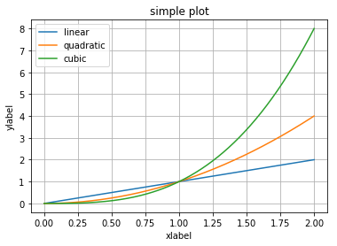

```python
import numpy as np
import matplotlib.pyplot as plt
x=np.linspace(0,2,200)
plt.plot(x,x,label='linear')
plt.plot(x,x**2,label='quadratic')
plt.plot(x,x**3,label='cubic')
plt.xlabel('xlabel')
plt.ylabel('ylabel')
plt.title('simple plot')
plt.grid(True)
plt.legend()
```

> 还有一些后端，配置文件设置的概念，没太看懂，参考[Usage Guide](https://matplotlib.org/tutorials/introductory/usage.html#backends)

### `Pyplot`教程

1. 基本绘制`plot()`函数  
   `plot()`函数类似matlab中绘图方法，甚至很多关键字参数都是一模一样的。
- 绘制一维数据。自动把给出的一维数据作为y，数据序号作为x
- 两个一维数据分别作为x,y坐标
- 用关键字参数设置`Line2D`对象的属性，就像matlab中设置线型、线宽、颜色、标志形状、标志颜色等，参看`help(plt.plot)`；当然也可以通过返回的`Line2D`对象（`plt.plot()`函数返回`Line2D`对象）设置其属性或者通过`plt.setp()`函数来设置线的属性
- 用subplot进行多图绘制，格式是`subplot(rows,cols,current)`，但是如果`rows`，`cols`乘积不大于10可以省略逗号
- 可以使用`plt.title()`,`plt.xlabel()`,`plt.legend()`,`plt.grid()`,`plt.hold`等设置标题、x标签、图例显示、网格显示、叠加绘图等
- `plot()`提供一个关键字参数`data`，允许使用字符串索引的变量作为x,y（如图3）
- 可以使用`scatter()`函数绘制离散图也可以设置`plot()`函数的`marker`参数画
- 可以使用`gcf()`获取当前图形，使用`gca()`获取当前坐标轴

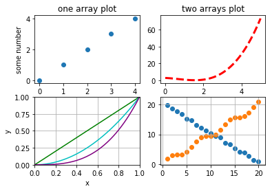

```python
import matplotlib.pyplot as plt
import numpy as np
plt.subplot(221)
plt.plot(np.arange(5),'o')
plt.ylabel('some number')
plt.title(r'one array plot')

plt.subplot(222)
x=np.linspace(0,5,100)
y=x**3-2*x**2-x+3
plt.plot(x,y,'r--',linewidth=3)
plt.title('two arrays plot')

ax=plt.subplot(223)
data={'x':np.linspace(0,1,100)}
data['y1']=data['x']
data['y2']=data['x']**2
data['y3']=data['x']**3
line1=plt.plot('x','y1',data=data)
line2=plt.plot('x','y2',data=data)
line3=plt.plot('x','y3',data=data)
ax.set_xlabel('x')
ax.set_ylabel('y')
plt.axis([0,1,0,1])
plt.setp(line1,'color','g')
plt.setp(line2,'color','c')
plt.setp(line3,'color','purple')
ax.grid(True)

plt.subplot(224)
ax=plt.gca()
x1=np.arange(1,21)
y1=max(x1)-x1+np.random.random(x1.shape)
x2=x1
y2=x2+np.sin(x2)
plt.scatter(x1,y1)
plt.scatter(x2,y2)
ax.grid(True)
```

1. 绘制文本
- `plt.text(x,y,text)`中`x`，`y`指定绘制文本的左下角坐标（在`Axes`中的坐标）；`text`指定绘制文本，文本以`r`开头，表示使用原始字符串（字符串的的反斜杠不作为python转义字符），`matplotlib`内置了TeX解析器，所以可以在文本中使用TeX公式，直接用两个`$`符号包起来的就是公式；当然，`r`字面量和TeX公式也可以用在其他的字符串里，比如`plt.title()`，`plt.xlabel()`中
- `plt.annotate(text,xy,xytext,arrowprops)`中`text`指定注释的内容，元组`xy`指定箭头指向的坐标位置，元组`xytext`指定文本位置左下角坐标，`arrowprops`指定一个代表箭头属性的字典
- 关于`Text`对象的其他属性参考[文本属性与布局](https://matplotlib.org/tutorials/text/text_props.html)；关于注释的用法参考[注释初级用法](https://matplotlib.org/tutorials/text/annotations.html#basic-annotation)与[注释高级用法](https://matplotlib.org/tutorials/text/annotations.html#advanced-annotation)

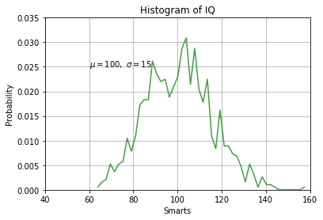

```python
mu,sigma=100,15
x=np.random.normal(mu,sigma,1000)
n,bins=np.histogram(x,50,density=1)
plt.plot(0.5*(bins[:-1]+bins[1:]),n,'g',alpha=0.75)
plt.xlabel('Smarts')
plt.ylabel('Probability')
plt.title('Histogram of IQ')
plt.axis([40, 160, 0, 0.035])
plt.grid(True)
plt.text(60,0.025,r'$\mu=100,\ \sigma=15$')
```

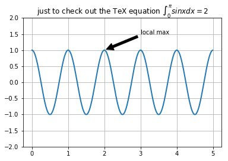

```python
ax=plt.subplot(111)
t=np.arange(0.0,5.0,0.01)
s=np.cos(2*np.pi*t)
line=plt.plot(t,s,lw=2)
plt.annotate('local max',xy=(2.0,1.0),xytext=(3.0,1.5),arrowprops=dict(facecolor='black',shrink=0.05))
plt.ylim(-2,2)
plt.grid(True)
plt.title(r'just to check out the TeX equation $\int_{0}^{\pi}sinxdx=2$')
```

1. 官方建议  
   基于`matplotlib`中有两套接口（基于状态的`pyplot`接口和面向对象的接口）,官方建议使用面向对象的接口，即使用`pyplot`生成`figure.Figure`对象与/或`axes.Axes`对象（`Figure`对象是整个图像，包含多个`Axes`；`Axes`对象对应一幅图像），使用`Axes`对象来设置各个属性，参考[A note on the Object-Oriented API vs Pyplot](https://matplotlib.org/tutorials/introductory/lifecycle.html#a-note-on-the-object-oriented-api-vs-pyplot)，比如:

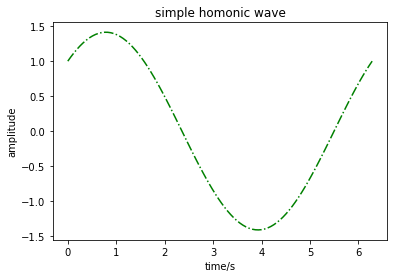

```python
import matplotlib.pyplot as plt
import numpy as np
t=np.linspace(0,2*np.pi,100)
y=np.sin(t)+np.cos(t)
fig,ax=plt.subplots()
ax.plot(t,y,'g-.')
ax.set_title('simple homonic wave')
ax.set_xlabel('time/s')
ax.set_ylabel('amplitude')
fig.savefig('test.png')
```

### `matplotlib`绘图功能概览

参看[Sample plot](https://matplotlib.org/tutorials/introductory/sample_plots.html)，主要有：

- 线条绘制`plot()`
- 多图绘制`subplot()`
- 图片绘制`imshow()`
- 等高线绘制`contour()`或者伪彩色图绘制`pcolormesh()`
- 直方图绘制`hist()`
- 路径绘制
- 三维图绘制（plot3d工具箱）
- 流线图绘制`streamplot()`
- 柱状图绘制`bar()`
- 饼状图绘制`pie()`
- 表格图绘制`table()`
- 离散图绘制`scatter()`
- 可视化控件
- 填充曲线绘制`fill()`
- 时序图绘制
- 对数坐标`semilogx()`,`semilogy()`,`loglog()`
- 极坐标`polar()`
- 图例绘制`legend()`
- 本地TeX渲染
- 控件内嵌绘图

### 图片显示教程

图片显示教程与数据分析处理不太相关，感兴趣可以进一步看看[Image Tutorial](https://matplotlib.org/tutorials/introductory/images.html)

### 绘图的全生命周期

1. 绘图对象创建  
   使用`plt.subplots()`即可返回一个`Figure`对象和一个`Axes`对象

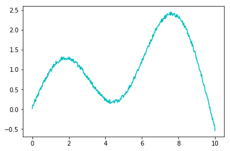

```python
import matplotlib.pyplot as plt
import numpy as np
x=np.linspace(0,10,400)
y=0.1*x**2-0.01*x**3+np.sin(x)+0.1*np.random.random(x.shape)
fig,ax=plt.subplots()
ax.plot(x,y,'c-')
```

1. 风格控制  
   改变绘图风格可使用`plt.style.use()`，欲了解都有哪些支持的绘图风格可使用`print(plt.style.available)`，各种风格差异无非是初始的图像背景色、画板背景色、前景色、线型、网格是否开启、网格线条颜色、边框线型、图像大小等，这些应该都可以自定义

```python
print(plt.style.available)
```

[output not shown]

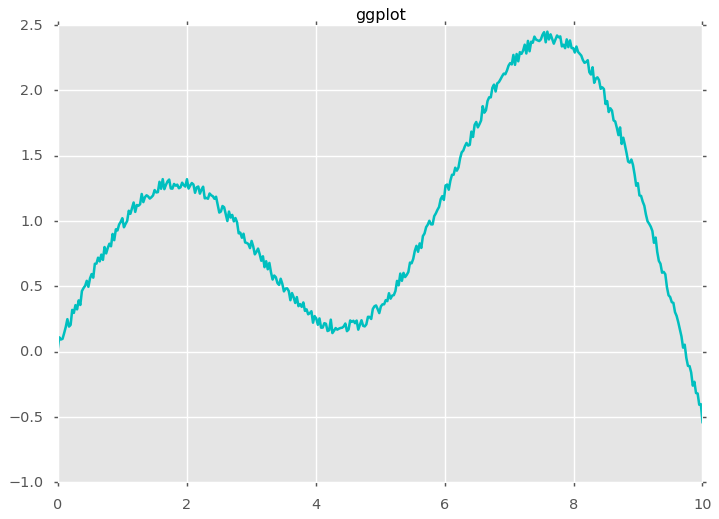

```python
plt.style.use('ggplot')#我觉得seaborn的几个风格和ggplot风格挺好看，classic、dark_background、fast都比较细线条、高对比度
fig,ax=plt.subplots()
ax.plot(x,y,'c-')
ax.set_title('ggplot')
#for style in plt.style.available:
#    plt.style.use(style)
#    fig,ax=plt.subplots()
#    ax.plot(x,y)
#    ax.set_title(style)
```

1. 自定义属性  
   包括设置`Axes`对象的标题、xy标签、xy刻度、刻度标签及其属性等

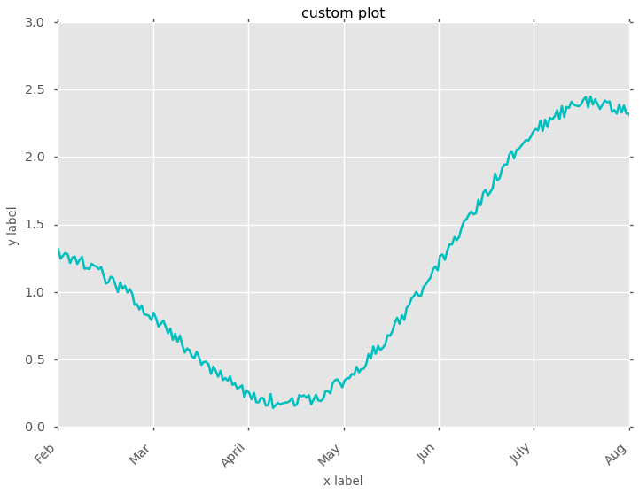

```python
from matplotlib.ticker import FuncFormatter
fig,ax=plt.subplots()
ax.plot(x,y,'c-')

#set函数可以直接按名设置图像的各个Artist对象
ax.set(xlim=[2,8],ylim=[0,3],title='custom plot',xlabel='x label',ylabel='y label')

#对具体的某个Artist对象的属性，需要先通过Axes对象获取该对象，然后通过plt.setp方法设置其属性
labels=ax.get_xticklabels()

#plt.setp函数可以同时设置某个matplotlib对象的多个属性
plt.setp(labels,rotation=45,horizontalalignment='right')

#使用Axes对象下的xaxis对象可以设置大小刻度的标签格式器
def month(x,pos):
    m=np.floor(x)
    return 'Jan' if m==1 else 'Feb' if m==2 else 'Mar' if m==3 else 'April' if m==4 else 'May' if m==5\
else 'Jun' if m==6 else 'July' if m==7 else 'Aug' if m==8 else 'Sep' if m==9 else 'Oct' if m==10 else 'Nov' if m==11 else 'Dec'

formatter=FuncFormatter(month)
ax.xaxis.set_major_formatter(formatter)
```

1. 多视图组合

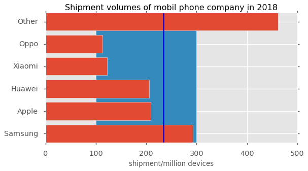

```python
import pandas as pd
df=pd.DataFrame(data=[['Samsung','Apple','Huawei','Xiaomi','Oppo','Other'],[292.3,208.8,206,122.6,113.1,462]])
df=df.transpose()
df.columns=['Company','Shipment']
df['Share']=df.apply(lambda x:x[1]/df['Shipment'].sum(),axis=1)

fig,ax=plt.subplots(figsize=(8,4))
ax.axvspan(100,300)
ax.barh(df['Company'],df['Shipment'])
ax.set_xlabel('shipment/million devices')
ax.set_title('Shipment volumes of mobil phone company in 2018')
ax.axvline(df['Shipment'].mean())
```

> 可以看出先画的图在下方，即为叠加绘图
1. 保存图  
   使用`fig.savefig`即可，欲了解支持的保存图片格式，可使用`print(fig.canvas.get_supported_filetypes())`

```python
print(fig.canvas.get_supported_filetypes())
```

[output not shown]

```python
fig.savefig('test1.jpg')
```

### 使用样式表和`rcParams`

个人认为使用以上提供的方法已能够改变绝大多数自定义属性了，使用样式表和rcParam大概只是为了设置`matplotlib`环境下的默认绘图属性。个人认为这是在写完备软件或者每次绘图样式都一样时将其设为默认，对于数据处理的交互式绘图其实没必要，毕竟没有人会在每次绘图时都打开配置文件去修改，故不做深入解释，参考[Customizing Matplotlib with style sheets and rcParams](https://matplotlib.org/tutorials/introductory/customizing.html)

## 中级

### `Artist`教程

所有的图像中的艺术元素都是`Artist`对象（比如标题、xy标签、xy刻度、图线、文本等），如上所述，`matplotlib`中有三个层次的API，

- matplotlib.backend_bases.FigureCanvas是图像绘制的区域
- matplotlib.backend_bases.Renderer是知道如何在FigureCanvas上绘制的对象
- matplotlib.artist.Artist是知道如何使用renderer向canvas绘图的对象

前两个处理底层或者说后端的绘图细节，用户95%时间都是与`Artist`打交道，无需关心前两层API。`Artist`对象中有两类——原始类型(primitives)与容器类型(containers)，原始类型是直接绘制到画布上的对象，如`Line2D`，`Rectangle`，`Text`，`AxesImage`等，容器类型是用来放置原始类型对象的地方，如`Axes`，`Axis`，`Figure`。常规做法是先生成`Figure`类对象(比如使用`plt.figure()`生成)，再用生成的`Figure`类对象生成`Axes`对象（比如`fig.add_subplot()`或者`fig.add_axes()`），之后再由`Axes`对象生成原始类型对象(比如`Axes.plot()`函数可生成`Line2D`对象)；`Axes`可能是`matplotlib`中最重要的类，大部分原始类型对象都是放在`Axes`下的列表中，比如Axes.lines列表包含了所有该坐标轴下添加的`Line2D`对象，大部分`pylot`中的绘图函数也是对`Axes`的成员方法的封装，比如`plt.plot()`与`Axes.plot()`、`plt.xlabel()`与`Axes.set_xlabel()`等等。

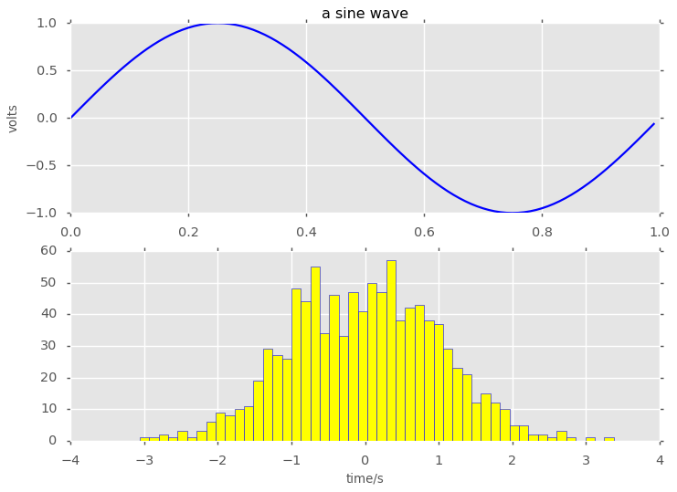

```python
fig=plt.figure()
ax=fig.add_subplot(2,1,1)
ax2=fig.add_subplot(2,1,2)
t=np.arange(0.0,1.0,0.01)
s=np.sin(2*np.pi*t)
line,=ax.plot(t,s,'b',lw=2)#`line,`表示解包，因为ax.plot()函数返回的是一个列表，解包了之后line是该列表中的第一个元素
#以下方法可以删除画出的线，可见plot()函数其实是把Axes对象下的lines列表更新了，添加了一个Line2D对象而已
#del ax.lines[0]
#ax.lines.remove(line)
ax.set_ylabel('volts')
ax.set_title('a sine wave')
ax2.hist(np.random.randn(1000),50,facecolor='yellow',edgecolor='blue')
ax2.set_xlabel('time/s')
```

所有的`Artist`对象都有`patch`成员变量，patch表示该`Artist`绘制的一些基本属性（区域——或矩形或圆形或多边形等、透明度、可见性、文本标签等等），参考[定制对象属性](https://matplotlib.org/tutorials/intermediate/artists.html#customizing-your-objects)

```python
import matplotlib as mpl
mpl.artist.getp(fig.patch)
```

```
    agg_filter = None
    alpha = None
    animated = False
    antialiased = False
    bbox = Bbox(x0=0.0, y0=0.0, x1=1.0, y1=1.0)
    capstyle = butt
    children = []
    clip_box = None
    clip_on = True
    clip_path = None
    contains = None
    data_transform = BboxTransformTo(     TransformedBbox(         Bbox...
    edgecolor = (0.5, 0.5, 0.5, 1.0)
    extents = Bbox(x0=0.0, y0=0.0, x1=832.0, y1=572.0)
    facecolor = (1.0, 1.0, 1.0, 1.0)
    figure = Figure(832x572)
    fill = True
    gid = None
    hatch = None
    height = 1
    in_layout = True
    joinstyle = miter
    label =
    linestyle = solid
    linewidth = 0.0
    patch_transform = CompositeGenericTransform(     BboxTransformTo(   ...
    path = Path(array([[0., 0.],        [1., 0.],        [1.,...
    path_effects = []
    picker = None
    rasterized = None
    sketch_params = None
    snap = None
    transform = CompositeGenericTransform(     CompositeGenericTra...
    transformed_clip_path_and_affine = (None, None)
    url = None
    verts = [[  0.   0.]  [832.   0.]  [832. 572.]  [  0. 572....
    visible = True
    width = 1
    window_extent = Bbox(x0=0.0, y0=0.0, x1=832.0, y1=572.0)
    x = 0
    xy = (0, 0)
    y = 0
    zorder = 1
```

对象容器——  
`matplotlib`中容器等级为：

```
cmd
Figure-
    Axes-
        Axis-
            Tick
```

`Axes`类中有许多帮助函数，用于绘图（其实就是生成对应的`Artist`对象并保存在`Axes`对应的列表中），包括

| 函数 | 作用 | 添加的Artist对象 | 列表容器 |
| --- | --- | --- | --- |
| ax.annotate | 添加注释 | Annotate | ax.texts |
| ax.bar | 绘制柱状图 | Rectangle | ax.patches |
| ax.errorbar | 误差柱状图 | Line2D和Rectangle | ax.lines和ax.patches |
| ax.fill | 填充多边形 | Polygon | ax.patches |
| ax.hist | 直方图 | Rectangle | ax.patches |
| ax.imshow | 显示图片 | Axesimage | ax.images |
| ax.legend | 图例 | Legend | ax.lengends |
| ax.plot | x y数据绘制 | Line2D | ax.lines |
| ax.scatter | 离散点绘制 | PolygonCollection | ax.collections |
| ax.text | 绘制文本 | Text | ax.texts |

更多的`Figure`、`Axes`、`Axis`、`Tick`属性可以参考[Object containers](https://matplotlib.org/tutorials/intermediate/artists.html#object-containers)

> 中级教程的剩余部分包括图例、多图绘制的布局及其布局限制以及高级教程部分就不一一列出了，更多的也不过是一些细节及高级用法的记忆，可以在使用过程中逐步了解与记忆。[matplotlib教程链接](https://matplotlib.org/tutorials/index.html)。

# Pandas教程

## 数据结构介绍

pandas的主要数据结构是带有标签的一维序列`Series`和二维数据`DataFrame`，类似于numpy中的一维、二维数组，事实上numpy中的很多使用`ndarray`作为输入的函数都可以无障碍地使用pandas中的数据结构，且行为如预期无二致。pandas的数据结构与一般的序列或多维数组最大的不同是数据**自动对齐功能**。所谓的数据自动对齐功能是指，如果两个`Series`相加，会把`Series`里对应index的数据相加而不管其真实的顺序；两个`DataFrame`相加会把对应index、对应column的数据相加也不管其真实的顺序。index、column相当于“行号”、“列号”。

### `Series`

1.`Series`生成——`Series(data,index)`

`Series`的index（注：index可以不给出）就如同字典的键，如果把`Series`看做列向量，index就如同“行号”,如同行的名称。

- 由python字典生成。如果没指定index则使用字典的键值作为index，如果指定了index，则相当于把`Series`中对应index的元素设为字典中对应该键的元素——如果字典中不存在该键，则使用numpy.nan类型表示无意义缺失数据（pandas中缺失数据的统一表示方式）；如果字典中有的键不在index中，则该键对应的值不取
- 由ndarray生成。如果不指定index则自动生成一个`range(data.size)`作为index；如果指定index，则index列表的长度必须与ndarray数据size相符
- 由一个数生成。指定index则把各个index对应的元素设为该数；不指定则生成一个长度为1的`Series`

```python
import pandas as pd
import numpy as np
d={'b':1,'c':3,'a':0}
s1=pd.Series(d)
s11=pd.Series(d,index=['b','c','d'])
print(s1)
print(s11)
```

```
b    1
c    3
a    0
dtype: int64
b    1.0
c    3.0
d    NaN
dtype: float64
```

```python
s2=pd.Series(np.random.rand(5))
s22=pd.Series(np.random.rand(5),index=['row1','row2','row3','row4','row5'])
print(s2)
print(s22)
```

```
0    0.306600
1    0.623135
2    0.708642
3    0.553359
4    0.831509
dtype: float64
row1    0.138651
row2    0.512370
row3    0.790319
row4    0.457625
row5    0.514766
dtype: float64
```

```python
s3=pd.Series(5,index=['a','b','c','d','e'])
s33=pd.Series(4)
print(s3)
print(s33)
```

```
a    5
b    5
c    5
d    5
e    5
dtype: int64
0    4
dtype: int64
```

1. `Series`索引与切片  
   `Series`既类似于`ndarray`，又类似与字典——既可以进行`ndarray`式的序号切片或者布尔值索引切片（切片的时候index一起切），而且大部分numpy的函数也可以使用`Series`做参数；又可以使用字典式的键值索引：

```python
s2.index=['a','b','c','d','e']
```

```python
s2[2]
```

```
0.7086422105658101
```

```python
s2[:-1]
```

```
a    0.306600
b    0.623135
c    0.708642
d    0.553359
dtype: float64
```

```python
s2[1:]
```

```
b    0.623135
c    0.708642
d    0.553359
e    0.831509
dtype: float64
```

```python
s2[[4,3,1]]
```

```
e    0.831509
d    0.553359
b    0.623135
dtype: float64
```

```python
s2[s2>s2.median()]
```

```
c    0.708642
e    0.831509
dtype: float64
```

```python
np.exp(s2)
```

```
a    1.358797
b    1.864765
c    2.031231
d    1.739085
e    2.296781
dtype: float64
```

1. 名称属性  
   `Series`有`name`属性，即可给`Series`命名，其实`Series`相当于`DataFrame`里的列，给其命名相当于给定“列号”/列的名称

```python
s1.name='something'
s11=s1.rename('another thing')#重命名生成了一个改变了名字的Series,原来的Series并不变
print(s1.name)
print(s1 is s11)
```

```
something
False
```

1. 向量化操作与数据对齐  
   一般的按位运算以及numpy中的数学函数等行为与numpy的`ndarray`一样；但是因为`Series`有自动对齐功能，所以这里的按位并不是按照序号相同的元素进行相应操作，而是按照index相同的元素进行按位操作——这样可以无需考虑两个按位运算的`Series`是否元素数一样，因为会自动对齐，比如：

   ```
   >>>s1
   a   1.0
   b   2.0
   c   3.0
   d   4.0
   dtype:float64
   >>>s2
   c   3.5
   d   2.4
   e   5.2
   stype:float64
   ```

   这样两个`Series`，其index不一致，如果计算`s1+s2`时，会先自动对齐，s1缺index e，s2缺index a,b，会自定补齐为:

   ```
   cmd
     s1            s2
   a   1.0        a   NaN
   b   2.0        b   NaN
   c   3.0        c   3.5
   d   4.0        d   2.4
   e   NaN        e   5.2
   ```

   所以

   ```
   >>>s1+s2
   a   NaN
   b   NaN
   c   6.5
   d   6.4
   e   NaN
   ```

   基于`Series`的自动对齐功能，其按位运算其实是按index位运算，两个`Series`相加行数等于两个`Series`中行名称不同的行数，结果的各行数据为加数的对应行数据之和，这使得错位加法与numpy中结果不同，如下：

```python
s=pd.Series(np.random.rand(5),index=['a','b','c','d','e'])
s
```

```
a    0.143963
b    0.928369
c    0.817016
d    0.967723
e    0.161322
dtype: float64
```

```python
s+s
```

```
a    0.287927
b    1.856737
c    1.634033
d    1.935446
e    0.322645
dtype: float64
```

```python
s**2
```

```
a    0.020725
b    0.861868
c    0.667516
d    0.936488
e    0.026025
dtype: float64
```

```python
np.sin(s)
```

```
a    0.143466
b    0.800644
c    0.729107
d    0.823597
e    0.160624
dtype: float64
```

```python
s[:-1]+s[1:]#数据自动对齐
```

```
a         NaN
b    1.856737
c    1.634033
d    1.935446
e         NaN
dtype: float64
```

### `DataFrame`

#### `DataFrame`生成——pd.DataFrame(data,index,columns)

index与column相当于行名称、列名称（生成时可以不给定）,data的类型可以是：

- 字典。字典的键是列名称，字典的元素可以是`Series`，也可以是字典（先转化成`Series`），也可以是`ndarray`或者列表（要求`ndarray`/列表的长度一致）；字典的值还可以是元组，这是创建MultiIndexed frame的方法，不常见也更复杂。
- `Series`。单列的数据表。
- 列表。列表的元素可以是字典（注意这里每个字典对应一行数据，而不是一列了；缺失列为NaN）;也可以是`Series`，同样一个`Series`表示一行，很有可能字典在这里也是先转化成`Series`；还可以是列表，这样行列名称都是自动编号
- 二维`ndarray`。就像二维列表一样，不给定index与columns参数行列自动编号

```python
d={'col1':pd.Series([1,2,3,4],index=['a','b','c','d']),
   'col2':pd.Series([1,2,3],index=['a','b','c'])}
df=pd.DataFrame(d)
df
```

|  | col1 | col2 |
| --- | --- | --- |
| a | 1 | 1.0 |
| b | 2 | 2.0 |
| c | 3 | 3.0 |
| d | 4 | NaN |

```python
pd.DataFrame(d,index=['d','b','a'])
```

|  | col1 | col2 |
| --- | --- | --- |
| d | 4 | NaN |
| b | 2 | 2.0 |
| a | 1 | 1.0 |

```python
pd.DataFrame(d,index=['d','b','a'],columns=['col1','col2','col3'])
```

|  | col1 | col2 | col3 |
| --- | --- | --- | --- |
| d | 4 | NaN | NaN |
| b | 2 | 2.0 | NaN |
| a | 1 | 1.0 | NaN |

```python
df.index
```

```
Index(['a', 'b', 'c', 'd'], dtype='object')
```

```python
df.columns
```

```
Index(['col1', 'col2'], dtype='object')
```

```python
#字典的值是列表时列表的尺寸必须一致了，因为这里是生成默认的index，无法知道哪个index对应的数据不存在
d={'col1':[1,2,3,4],'col2':[4,3,2,1]}
df=pd.DataFrame(d)
df
```

|  | col1 | col2 |
| --- | --- | --- |
| 0 | 1 | 4 |
| 1 | 2 | 3 |
| 2 | 3 | 2 |
| 3 | 4 | 1 |

```python
pd.DataFrame(d,index=['a','b','c','d'])
```

|  | col1 | col2 |
| --- | --- | --- |
| a | 1 | 4 |
| b | 2 | 3 |
| c | 3 | 2 |
| d | 4 | 1 |

```python
pd.DataFrame(d,columns=['col2','col3'])
```

|  | col2 | col3 |
| --- | --- | --- |
| 0 | 4 | NaN |
| 1 | 3 | NaN |
| 2 | 2 | NaN |
| 3 | 1 | NaN |

```python
s1=pd.Series([1,2,3,4,5])
s1.name='one'
pd.DataFrame(s1)
```

|  | one |
| --- | --- |
| 0 | 1 |
| 1 | 2 |
| 2 | 3 |
| 3 | 4 |
| 4 | 5 |

```python
s2=s1.rename('two')
pd.DataFrame([s1,s2])
```

|  | 0 | 1 | 2 | 3 | 4 |
| --- | --- | --- | --- | --- | --- |
| one | 1 | 2 | 3 | 4 | 5 |
| two | 1 | 2 | 3 | 4 | 5 |

```python
data=[{'a':1,'b':2,'c':3},{'b':4,'c':7,'d':9},{'a':6,'c':3,'d':5}]
pd.DataFrame(data)
```

|  | a | b | c | d |
| --- | --- | --- | --- | --- |
| 0 | 1.0 | 2.0 | 3 | NaN |
| 1 | NaN | 4.0 | 7 | 9.0 |
| 2 | 6.0 | NaN | 3 | 5.0 |

```python
data=[[1,2,3,4],[5,6,7,8],[9,8,7,6]]
pd.DataFrame(data)
```

|  | 0 | 1 | 2 | 3 |
| --- | --- | --- | --- | --- |
| 0 | 1 | 2 | 3 | 4 |
| 1 | 5 | 6 | 7 | 8 |
| 2 | 9 | 8 | 7 | 6 |

```python
pd.DataFrame(np.random.rand(3,4),index=[1,2,3])
```

|  | 0 | 1 | 2 | 3 |
| --- | --- | --- | --- | --- |
| 1 | 0.192573 | 0.730975 | 0.841481 | 0.931627 |
| 2 | 0.293800 | 0.053102 | 0.338191 | 0.020721 |
| 3 | 0.317729 | 0.235391 | 0.718062 | 0.087604 |

#### 列选中、插入、删除

基本与字典的操作一，通过键索引列，得到的列是一个`Series`；添加、删除操作与字典也类似

```python
data=np.random.rand(4,3)
df=pd.DataFrame(data,index=['a','b','c','d'],columns=['one','two','three'])
df
```

|  | one | two | three |
| --- | --- | --- | --- |
| a | 0.081774 | 0.689690 | 0.137227 |
| b | 0.191447 | 0.185544 | 0.306146 |
| c | 0.954003 | 0.415900 | 0.434817 |
| d | 0.290428 | 0.441525 | 0.778144 |

```python
df['three'],type(df['three'])
```

```
(a    0.137227
 b    0.306146
 c    0.434817
 d    0.778144
 Name: three, dtype: float64, pandas.core.series.Series)
```

```python
df['four']=df['one']+df['two']
df
```

|  | one | two | three | four |
| --- | --- | --- | --- | --- |
| a | 0.081774 | 0.689690 | 0.137227 | 0.771464 |
| b | 0.191447 | 0.185544 | 0.306146 | 0.376992 |
| c | 0.954003 | 0.415900 | 0.434817 | 1.369902 |
| d | 0.290428 | 0.441525 | 0.778144 | 0.731953 |

```python
df['flag']=df['three']>0.5
df
```

|  | one | two | three | four | flag |
| --- | --- | --- | --- | --- | --- |
| a | 0.081774 | 0.689690 | 0.137227 | 0.771464 | False |
| b | 0.191447 | 0.185544 | 0.306146 | 0.376992 | False |
| c | 0.954003 | 0.415900 | 0.434817 | 1.369902 | False |
| d | 0.290428 | 0.441525 | 0.778144 | 0.731953 | True |

```python
df.insert(1,'oneandhalf',df['one'])#指定插入列位置为1
df
```

|  | one | oneandhalf | two | three | four | flag |
| --- | --- | --- | --- | --- | --- | --- |
| a | 0.081774 | 0.081774 | 0.689690 | 0.137227 | 0.771464 | False |
| b | 0.191447 | 0.191447 | 0.185544 | 0.306146 | 0.376992 | False |
| c | 0.954003 | 0.954003 | 0.415900 | 0.434817 | 1.369902 | False |
| d | 0.290428 | 0.290428 | 0.441525 | 0.778144 | 0.731953 | True |

```python
del df['three'],df['four'],df['oneandhalf']
df
```

|  | one | two | flag |
| --- | --- | --- | --- |
| a | 0.081774 | 0.689690 | False |
| b | 0.191447 | 0.185544 | False |
| c | 0.954003 | 0.415900 | False |
| d | 0.290428 | 0.441525 | True |

插入的列是一个标量时会自动应用广播法则（按列）

```python
df['foo']='bar'
df
```

|  | one | two | flag | foo |
| --- | --- | --- | --- | --- |
| a | 0.081774 | 0.689690 | False | bar |
| b | 0.191447 | 0.185544 | False | bar |
| c | 0.954003 | 0.415900 | False | bar |
| d | 0.290428 | 0.441525 | True | bar |

插入的列与DataFrame的行数、行名不一致时会自动对齐

```python
df['three']=df['one'][:2]
df
```

|  | one | two | flag | foo | three |
| --- | --- | --- | --- | --- | --- |
| a | 0.081774 | 0.689690 | False | bar | 0.081774 |
| b | 0.191447 | 0.185544 | False | bar | 0.191447 |
| c | 0.954003 | 0.415900 | False | bar | NaN |
| d | 0.290428 | 0.441525 | True | bar | NaN |

```python
df['four']=pd.Series([4,5],index=['d','e'])
df
```

|  | one | two | flag | foo | three | four |
| --- | --- | --- | --- | --- | --- | --- |
| a | 0.081774 | 0.689690 | False | bar | 0.081774 | NaN |
| b | 0.191447 | 0.185544 | False | bar | 0.191447 | NaN |
| c | 0.954003 | 0.415900 | False | bar | NaN | NaN |
| d | 0.290428 | 0.441525 | True | bar | NaN | 4.0 |

> 由上可知，df并没有增加名称为“e”的行——我的理解是自动对齐只对右值（等号右边的）有效，所以df并不会对齐之后再插入df['four']列，只将右边添加的列自动对齐；而下面的例子则会把df也自动对齐，因为df在等号右边。当然这些自动对齐都不是在原位上进行的，df本身数据仍然没有变

```python
df+pd.DataFrame(pd.Series([4,5],index=['d','e'],name='four'))
```

|  | flag | foo | four | one | three | two |
| --- | --- | --- | --- | --- | --- | --- |
| a | NaN | NaN | NaN | NaN | NaN | NaN |
| b | NaN | NaN | NaN | NaN | NaN | NaN |
| c | NaN | NaN | NaN | NaN | NaN | NaN |
| d | NaN | NaN | 8.0 | NaN | NaN | NaN |
| e | NaN | NaN | NaN | NaN | NaN | NaN |

```python
df
```

|  | one | two | flag | foo | three | four |
| --- | --- | --- | --- | --- | --- | --- |
| a | 0.081774 | 0.689690 | False | bar | 0.081774 | NaN |
| b | 0.191447 | 0.185544 | False | bar | 0.191447 | NaN |
| c | 0.954003 | 0.415900 | False | bar | NaN | NaN |
| d | 0.290428 | 0.441525 | True | bar | NaN | 4.0 |

#### 使用方法链赋值新列

使用`assign()`函数可以由已有列生成新列

```python
data=np.random.randn(4,5)*7+80
data[data>100]=100
data[data<60]=60
df=pd.DataFrame(data,index=['Li YX','Tang KS','Wang Q','Liu XH'],columns=['Engineering','English','Management','CS','Mechanics'])
df
```

|  | Engineering | English | Management | CS | Mechanics |
| --- | --- | --- | --- | --- | --- |
| Li YX | 75.987862 | 68.258449 | 74.933372 | 94.848686 | 85.861676 |
| Tang KS | 78.730984 | 74.675663 | 78.473013 | 70.628554 | 89.375882 |
| Wang Q | 79.579904 | 69.424659 | 74.911647 | 81.454416 | 77.725207 |
| Liu XH | 75.472634 | 82.423732 | 84.027502 | 81.709782 | 78.177159 |

`assign()`可用于由已有列生成新列

```python
df.assign(Total=df['Engineering']+df['English']+df['Management']+df['CS']+df['Mechanics'])
```

|  | Engineering | English | Management | CS | Mechanics | Total |
| --- | --- | --- | --- | --- | --- | --- |
| Li YX | 75.987862 | 68.258449 | 74.933372 | 94.848686 | 85.861676 | 399.890044 |
| Tang KS | 78.730984 | 74.675663 | 78.473013 | 70.628554 | 89.375882 | 391.884096 |
| Wang Q | 79.579904 | 69.424659 | 74.911647 | 81.454416 | 77.725207 | 383.095833 |
| Liu XH | 75.472634 | 82.423732 | 84.027502 | 81.709782 | 78.177159 | 401.810809 |

`assign()`中可以使用函数进行列的计算

```python
df.assign(Average=lambda x:np.sum(x,axis=1)/5)
```

|  | Engineering | English | Management | CS | Mechanics | Average |
| --- | --- | --- | --- | --- | --- | --- |
| Li YX | 75.987862 | 68.258449 | 74.933372 | 94.848686 | 85.861676 | 79.978009 |
| Tang KS | 78.730984 | 74.675663 | 78.473013 | 70.628554 | 89.375882 | 78.376819 |
| Wang Q | 79.579904 | 69.424659 | 74.911647 | 81.454416 | 77.725207 | 76.619167 |
| Liu XH | 75.472634 | 82.423732 | 84.027502 | 81.709782 | 78.177159 | 80.362162 |

可以对数据表中的符合条件的某几条记录（某几行）进行运算，这样不必对整个表进行计算（比如先进行查询再对查询结果计算）：

```python
df.query('Engineering>76')
```

|  | Engineering | English | Management | CS | Mechanics |
| --- | --- | --- | --- | --- | --- |
| Tang KS | 78.730984 | 74.675663 | 78.473013 | 70.628554 | 89.375882 |
| Wang Q | 79.579904 | 69.424659 | 74.911647 | 81.454416 | 77.725207 |

```python
df.query('CS>80').assign(GeneralEngineering=lambda x:(x['Engineering']+x['CS']+x['Mechanics'])/3)
```

|  | Engineering | English | Management | CS | Mechanics | GeneralEngineering |
| --- | --- | --- | --- | --- | --- | --- |
| Li YX | 75.987862 | 68.258449 | 74.933372 | 94.848686 | 85.861676 | 85.566074 |
| Wang Q | 79.579904 | 69.424659 | 74.911647 | 81.454416 | 77.725207 | 79.586509 |
| Liu XH | 75.472634 | 82.423732 | 84.027502 | 81.709782 | 78.177159 | 78.453192 |

`assign()`中使用的表达式中可以含有之前一个表达式计算得到的变量，如下。唯一有点小问题的是含有前一个表达式生成变量的表达式不能使用数据表来索引新生成的列，而只能使用`lambda`表达式（即匿名函数）,否则会出现键错误，因为调用函数把实参传进去时还没进行第一个表达式，所以不存在“Total”键，无法访问`df['Total']`，而使用`lambda`函数时并没有传进去具体的数据，只是传了一个函数的引用：

```python
df.assign(Total=lambda x:np.sum(x,axis=1),Average=lambda x:x['Total']/5)
#df.assign(Total=lambda x:np.sum(x,axis=1),Average=df['Total']/5)这个不行
```

|  | Engineering | English | Management | CS | Mechanics | Total | Average |
| --- | --- | --- | --- | --- | --- | --- | --- |
| Li YX | 75.987862 | 68.258449 | 74.933372 | 94.848686 | 85.861676 | 399.890044 | 79.978009 |
| Tang KS | 78.730984 | 74.675663 | 78.473013 | 70.628554 | 89.375882 | 391.884096 | 78.376819 |
| Wang Q | 79.579904 | 69.424659 | 74.911647 | 81.454416 | 77.725207 | 383.095833 | 76.619167 |
| Liu XH | 75.472634 | 82.423732 | 84.027502 | 81.709782 | 78.177159 | 401.810809 | 80.362162 |

#### 索引与选择

1. 选择列

```python
df['CS']
```

```
Li YX      94.848686
Tang KS    70.628554
Wang Q     81.454416
Liu XH     81.709782
Name: CS, dtype: float64
```

1. 按标签选择行

```python
df.loc['Tang KS']
```

```
Engineering    78.730984
English        74.675663
Management     78.473013
CS             70.628554
Mechanics      89.375882
Name: Tang KS, dtype: float64
```

1. 按序号选择行

```python
df.iloc[2]
```

```
Engineering    79.579904
English        69.424659
Management     74.911647
CS             81.454416
Mechanics      77.725207
Name: Wang Q, dtype: float64
```

1. 行切片

```python
df[:-1]
```

|  | Engineering | English | Management | CS | Mechanics |
| --- | --- | --- | --- | --- | --- |
| Li YX | 75.987862 | 68.258449 | 74.933372 | 94.848686 | 85.861676 |
| Tang KS | 78.730984 | 74.675663 | 78.473013 | 70.628554 | 89.375882 |
| Wang Q | 79.579904 | 69.424659 | 74.911647 | 81.454416 | 77.725207 |

1. 布尔值行索引

```python
df[df['English']>70]
```

|  | Engineering | English | Management | CS | Mechanics |
| --- | --- | --- | --- | --- | --- |
| Tang KS | 78.730984 | 74.675663 | 78.473013 | 70.628554 | 89.375882 |
| Liu XH | 75.472634 | 82.423732 | 84.027502 | 81.709782 | 78.177159 |

#### 数据对齐与算术

所谓数据对齐就是两个`DataFrame`进行算术运算时，最后的行数、列数等于两个表中不同的行数总和与不同的列数总和，即两个数据表行列标签取并集，然后对原数据表中行标签、列标签都相同的元素进行相应算术运算

```python
df1=pd.DataFrame(np.random.randn(4,6))
df2=pd.DataFrame(np.random.randn(3,4))
df1,df2,df1+df2
```

```
(          0         1         2         3         4         5
 0  0.004918 -0.633382 -0.862058  0.345601 -0.698983 -1.198451
 1  0.000996 -1.792127 -0.080231  0.546962  0.879534  0.048649
 2  0.619625 -0.192753 -0.060333  0.651259 -0.057265  0.720667
 3 -0.386628  1.493021  0.107017  0.586775  0.879709  0.559901,
           0         1         2         3
 0 -1.101043 -0.527273  0.801759  0.786621
 1 -0.757937 -1.220986 -1.169714 -0.757507
 2  1.671402 -1.451858  0.099088 -0.008609,
           0         1         2         3   4   5
 0 -1.096125 -1.160655 -0.060300  1.132223 NaN NaN
 1 -0.756941 -3.013113 -1.249945 -0.210546 NaN NaN
 2  2.291027 -1.644611  0.038755  0.642650 NaN NaN
 3       NaN       NaN       NaN       NaN NaN NaN)
```

```python
df1*5+2
```

|  | 0 | 1 | 2 | 3 | 4 | 5 |
| --- | --- | --- | --- | --- | --- | --- |
| 0 | 2.024591 | -1.166912 | -2.310291 | 3.728007 | -1.494916 | -3.992253 |
| 1 | 2.004981 | -6.960634 | 1.598845 | 4.734808 | 6.397671 | 2.243245 |
| 2 | 5.098124 | 1.036233 | 1.698336 | 5.256293 | 1.713677 | 5.603337 |
| 3 | 0.066858 | 9.465105 | 2.535085 | 4.933873 | 6.398544 | 4.799507 |

```python
1/df1
```

|  | 0 | 1 | 2 | 3 | 4 | 5 |
| --- | --- | --- | --- | --- | --- | --- |
| 0 | 203.328949 | -1.578825 | -1.160014 | 2.893508 | -1.430649 | -0.834411 |
| 1 | 1003.719277 | -0.557996 | -12.463998 | 1.828282 | 1.136966 | 20.555369 |
| 2 | 1.613880 | -5.187977 | -16.574722 | 1.535489 | -17.462777 | 1.387603 |
| 3 | -2.586462 | 0.669783 | 9.344318 | 1.704232 | 1.136740 | 1.786029 |

```python
df1=df1>0
df2=pd.DataFrame(np.random.randn(4,6))>0
df1,df2
```

```
(       0      1      2     3      4      5
 0   True  False  False  True  False  False
 1   True  False  False  True   True   True
 2   True  False  False  True  False   True
 3  False   True   True  True   True   True,
        0      1      2      3      4      5
 0  False   True  False  False  False   True
 1  False  False  False   True   True  False
 2   True   True   True  False  False  False
 3   True  False   True  False   True   True)
```

```python
df1&df2
```

|  | 0 | 1 | 2 | 3 | 4 | 5 |
| --- | --- | --- | --- | --- | --- | --- |
| 0 | False | False | False | False | False | False |
| 1 | False | False | False | True | True | False |
| 2 | True | False | False | False | False | False |
| 3 | False | False | True | False | True | True |

```python
-df1
```

|  | 0 | 1 | 2 | 3 | 4 | 5 |
| --- | --- | --- | --- | --- | --- | --- |
| 0 | False | True | True | False | True | True |
| 1 | False | True | True | False | False | False |
| 2 | False | True | True | False | True | False |
| 3 | True | False | False | False | False | False |

#### 转置

```python
df.T
```

|  | Li YX | Tang KS | Wang Q | Liu XH |
| --- | --- | --- | --- | --- |
| Engineering | 75.987862 | 78.730984 | 79.579904 | 75.472634 |
| English | 68.258449 | 74.675663 | 69.424659 | 82.423732 |
| Management | 74.933372 | 78.473013 | 74.911647 | 84.027502 |
| CS | 94.848686 | 70.628554 | 81.454416 | 81.709782 |
| Mechanics | 85.861676 | 89.375882 | 77.725207 | 78.177159 |

#### 与Numpy的互操作

主要数据表中的数据是数值类型，就能无障碍地使用numpy中的按位运算函数`ufunc`比如`np.exp`，`np.sum`，`np.log`，`np.sqrt`等等

```python
10*np.sqrt(df)
```

|  | Engineering | English | Management | CS | Mechanics |
| --- | --- | --- | --- | --- | --- |
| Li YX | 87.171017 | 82.618671 | 86.564064 | 97.390290 | 92.661575 |
| Tang KS | 88.730482 | 86.415081 | 88.584995 | 84.040796 | 94.538819 |
| Wang Q | 89.207569 | 83.321461 | 86.551515 | 90.252100 | 88.161900 |
| Liu XH | 86.874987 | 90.787517 | 91.666516 | 90.393463 | 88.417848 |

```python
s1=pd.Series(np.random.randn(5))
print(s1)
s1.dot(s1)#求内积
```

```
0    0.494698
1   -0.872681
2   -0.660089
3    0.677316
4    1.098060
dtype: float64
```

```
3.106507881403395
```

#### 列属性访问

数据表的列名可以像变量名一样，用于访问列

```python
df.CS
```

```
Li YX      94.848686
Tang KS    70.628554
Wang Q     81.454416
Liu XH     81.709782
Name: CS, dtype: float64
```

## `Pandas`十分钟教程

### 对象创建

在数据结构介绍中已经详细介绍了多种`Series`和`DataFrame`的创建方式——我觉得比较好的方式是生成`Series`时使用一维`ndarray`或列表，然后指定index；生成`DataFrame`时使用二维`ndarray`或二维列表，然后指定index与columns。如果要对行列标签有更大的掌控权，比如生成二维的数据表时如果要指定哪些行列处的数据缺失，可以使用字典的字典，或者`Series`的字典

```python
import pandas as pd
import numpy as np
s1=pd.Series([1,4,3,np.nan,6,8],index=list(range(6)))
s2=pd.Series(np.empty(4),index=list(range(4)))
df1=pd.DataFrame([[1,2,5,8],[2,5,9,3],[7,5,2,0]],index=['a','b','c'],columns=['one','two','three','four'])
df2=pd.DataFrame(np.random.randn(4,5),index=list('abcd'),columns=list('ABCDE'))
print('s1=')
print(s1)
print('s2=')
print(s2)
print('df1=')
print(df1)
print('df2=')
print(df2)
```

```
s1=
0    1.0
1    4.0
2    3.0
3    NaN
4    6.0
5    8.0
dtype: float64
s2=
0    0.832745
1    1.104834
2    0.883904
3    1.908310
dtype: float64
df1=
   one  two  three  four
a    1    2      5     8
b    2    5      9     3
c    7    5      2     0
df2=
          A         B         C         D         E
a  0.707744  0.673457 -0.318665  1.233817  0.285659
b -0.282963  1.230763 -0.137744 -1.696618 -1.321815
c -1.125456 -1.045406 -0.482601 -0.048063 -0.860286
d  0.027825  1.219672 -0.664755 -0.581099  0.747367
```

上面已经讲过，`DataFrame`的列可以像变量一样被索引，那么如果列名称刚好和一个变量重名会怎么办?

```python
df=pd.DataFrame({'assign':{'a':1,'b':2,'c':3},
                 'T':{'a':4,'c':7}})
#df
#df.assign(five=df['assign']+df['T'])
df.assign
df['assign']
#df.T
#df['T']
```

```
a    1
b    2
c    3
Name: assign, dtype: int64
```

> 事实证明，如果列名与变量名或函数名重名，将不能再通过变量方式访问，同名的函数与变量使用不受影响

### 数据查看

#### 查看首尾部分记录

```python
df=pd.DataFrame(np.random.randn(40,5),index=list(range(1,41)),columns=list('ABCDE'))
df.head()#默认5条记录
```

|  | A | B | C | D | E |
| --- | --- | --- | --- | --- | --- |
| 1 | -0.062101 | -1.078257 | 1.177289 | -0.027442 | 1.211772 |
| 2 | 0.103013 | 0.392008 | 1.630711 | 1.274753 | 0.021503 |
| 3 | 2.076479 | -0.596327 | -0.180816 | -1.539962 | 0.900922 |
| 4 | -1.089340 | -0.616007 | 0.402037 | 0.012556 | -1.368815 |
| 5 | -0.380664 | -0.752829 | 0.286627 | -0.660762 | 0.583335 |

```python
df.head(3)
```

|  | A | B | C | D | E |
| --- | --- | --- | --- | --- | --- |
| 1 | -0.062101 | -1.078257 | 1.177289 | -0.027442 | 1.211772 |
| 2 | 0.103013 | 0.392008 | 1.630711 | 1.274753 | 0.021503 |
| 3 | 2.076479 | -0.596327 | -0.180816 | -1.539962 | 0.900922 |

```python
df.tail()
```

|  | A | B | C | D | E |
| --- | --- | --- | --- | --- | --- |
| 36 | 0.435087 | 0.796471 | 0.366780 | -0.388796 | 0.168838 |
| 37 | 0.760828 | 0.063407 | -0.523649 | -0.021345 | -1.238092 |
| 38 | -1.429357 | 0.744888 | 0.135597 | 0.237871 | 0.721818 |
| 39 | 0.681052 | 0.120146 | -0.341561 | -0.074470 | 2.644202 |
| 40 | 0.487668 | 3.104073 | 0.706086 | 0.885964 | 0.344888 |

#### 查看表的行列号

```python
df.index
```

```
Int64Index([ 1,  2,  3,  4,  5,  6,  7,  8,  9, 10, 11, 12, 13, 14, 15, 16, 17,
            18, 19, 20, 21, 22, 23, 24, 25, 26, 27, 28, 29, 30, 31, 32, 33, 34,
            35, 36, 37, 38, 39, 40],
           dtype='int64')
```

```python
df.columns
```

```
Index(['A', 'B', 'C', 'D', 'E'], dtype='object')
```

#### 查看表的基本统计信息

```python
df.describe()
```

|  | A | B | C | D | E |
| --- | --- | --- | --- | --- | --- |
| count | 40.000000 | 40.000000 | 40.000000 | 40.000000 | 40.000000 |
| mean | 0.166118 | 0.098793 | -0.058017 | -0.341744 | -0.089269 |
| std | 0.926913 | 1.045696 | 1.210106 | 0.797258 | 0.978599 |
| min | -1.696426 | -1.764623 | -2.926615 | -2.001535 | -2.018404 |
| 25% | -0.433330 | -0.601247 | -0.803333 | -0.739267 | -0.861654 |
| 50% | 0.206066 | 0.053874 | 0.211112 | -0.221885 | -0.014662 |
| 75% | 0.735050 | 0.796908 | 0.685702 | 0.171243 | 0.635587 |
| max | 2.076479 | 3.104073 | 1.854809 | 1.274753 | 2.644202 |

```python
df.describe().loc['std']
```

```
A    0.926913
B    1.045696
C    1.210106
D    0.797258
E    0.978599
Name: std, dtype: float64
```

#### 转置

```python
df.T
```

|  | 1 | 2 | 3 | 4 | 5 | 6 | 7 | 8 | 9 | 10 | ... | 31 | 32 | 33 | 34 | 35 | 36 | 37 | 38 | 39 | 40 |
| --- | --- | --- | --- | --- | --- | --- | --- | --- | --- | --- | --- | --- | --- | --- | --- | --- | --- | --- | --- | --- | --- |
| A | -0.062101 | 0.103013 | 2.076479 | -1.089340 | -0.380664 | -1.378901 | 0.561948 | 0.314089 | -1.596442 | 1.299213 | ... | 0.703694 | -0.274134 | 0.870909 | -0.549939 | -1.020007 | 0.435087 | 0.760828 | -1.429357 | 0.681052 | 0.487668 |
| B | -1.078257 | 0.392008 | -0.596327 | -0.616007 | -0.752829 | -1.296149 | -0.134572 | 0.264684 | -1.322799 | -0.109218 | ... | -0.482973 | -1.405206 | 0.236889 | 0.951827 | -0.022907 | 0.796471 | 0.063407 | 0.744888 | 0.120146 | 3.104073 |
| C | 1.177289 | 1.630711 | -0.180816 | 0.402037 | 0.286627 | 0.678908 | -0.767582 | -0.910587 | -2.426908 | -2.303974 | ... | -1.591000 | 1.758062 | 1.854809 | -1.174188 | -1.254712 | 0.366780 | -0.523649 | 0.135597 | -0.341561 | 0.706086 |
| D | -0.027442 | 1.274753 | -1.539962 | 0.012556 | -0.660762 | -0.609406 | 0.714209 | -0.993118 | 0.527024 | -1.838867 | ... | -0.272210 | -0.008618 | -1.601432 | -1.841561 | 0.106945 | -0.388796 | -0.021345 | 0.237871 | -0.074470 | 0.885964 |
| E | 1.211772 | 0.021503 | 0.900922 | -1.368815 | 0.583335 | 0.635168 | 0.067721 | -2.018404 | -0.403593 | -0.550381 | ... | -0.668063 | -0.664433 | -0.577484 | -1.132124 | 0.813831 | 0.168838 | -1.238092 | 0.721818 | 2.644202 | 0.344888 |

5 rows × 40 columns

```python
df.transpose()
```

|  | 1 | 2 | 3 | 4 | 5 | 6 | 7 | 8 | 9 | 10 | ... | 31 | 32 | 33 | 34 | 35 | 36 | 37 | 38 | 39 | 40 |
| --- | --- | --- | --- | --- | --- | --- | --- | --- | --- | --- | --- | --- | --- | --- | --- | --- | --- | --- | --- | --- | --- |
| A | -0.062101 | 0.103013 | 2.076479 | -1.089340 | -0.380664 | -1.378901 | 0.561948 | 0.314089 | -1.596442 | 1.299213 | ... | 0.703694 | -0.274134 | 0.870909 | -0.549939 | -1.020007 | 0.435087 | 0.760828 | -1.429357 | 0.681052 | 0.487668 |
| B | -1.078257 | 0.392008 | -0.596327 | -0.616007 | -0.752829 | -1.296149 | -0.134572 | 0.264684 | -1.322799 | -0.109218 | ... | -0.482973 | -1.405206 | 0.236889 | 0.951827 | -0.022907 | 0.796471 | 0.063407 | 0.744888 | 0.120146 | 3.104073 |
| C | 1.177289 | 1.630711 | -0.180816 | 0.402037 | 0.286627 | 0.678908 | -0.767582 | -0.910587 | -2.426908 | -2.303974 | ... | -1.591000 | 1.758062 | 1.854809 | -1.174188 | -1.254712 | 0.366780 | -0.523649 | 0.135597 | -0.341561 | 0.706086 |
| D | -0.027442 | 1.274753 | -1.539962 | 0.012556 | -0.660762 | -0.609406 | 0.714209 | -0.993118 | 0.527024 | -1.838867 | ... | -0.272210 | -0.008618 | -1.601432 | -1.841561 | 0.106945 | -0.388796 | -0.021345 | 0.237871 | -0.074470 | 0.885964 |
| E | 1.211772 | 0.021503 | 0.900922 | -1.368815 | 0.583335 | 0.635168 | 0.067721 | -2.018404 | -0.403593 | -0.550381 | ... | -0.668063 | -0.664433 | -0.577484 | -1.132124 | 0.813831 | 0.168838 | -1.238092 | 0.721818 | 2.644202 | 0.344888 |

5 rows × 40 columns

#### 排序

```python
df.sort_index(axis=1,ascending=False).head()
```

|  | E | D | C | B | A |
| --- | --- | --- | --- | --- | --- |
| 1 | 1.211772 | -0.027442 | 1.177289 | -1.078257 | -0.062101 |
| 2 | 0.021503 | 1.274753 | 1.630711 | 0.392008 | 0.103013 |
| 3 | 0.900922 | -1.539962 | -0.180816 | -0.596327 | 2.076479 |
| 4 | -1.368815 | 0.012556 | 0.402037 | -0.616007 | -1.089340 |
| 5 | 0.583335 | -0.660762 | 0.286627 | -0.752829 | -0.380664 |

```python
df.sort_values(by='A',ascending=False).head(7)
```

|  | A | B | C | D | E |
| --- | --- | --- | --- | --- | --- |
| 3 | 2.076479 | -0.596327 | -0.180816 | -1.539962 | 0.900922 |
| 11 | 1.798114 | -0.581744 | -0.000794 | -0.734695 | 1.707054 |
| 13 | 1.494819 | 0.818553 | -1.321054 | -0.508548 | -0.847334 |
| 20 | 1.435224 | 0.878503 | 0.378203 | 0.286078 | -0.943247 |
| 10 | 1.299213 | -0.109218 | -2.303974 | -1.838867 | -0.550381 |
| 15 | 1.259794 | 0.457626 | 0.104392 | -0.038785 | 0.636846 |
| 30 | 1.058007 | -0.061558 | 0.380465 | -0.660160 | 0.991072 |

### 数据读写

#### 数据访问

前面数据结构的部分已经讲了`[]`方式索引列、行切片、布尔值索引，以及使用`loc[]`方式的按名索引行和使用`iloc[]`的按序号索引行；总结来说：

- `[]`更像是一种直观的、快捷的索引方式，但是相对来说一个语境一个语法，缺乏规则性，各个用法能记住最好
- `loc[]`是标签索引，用标签来索引行、列，用逗号分开行、列的标签，还可以进行切片，基本与直观的意思无差别
- `iloc[]`是序号索引，使用行列序号来进行索引，用逗号隔开行、列索引，其用法与matlab几乎雷同，对于matlab用户来说简直就是breeze
- `at[]`就像是`loc[]`的mini版，使用行列标签进行索引，区别是不可以进行切片，只能用来索引单个值
- `iat[]`同样的是`iloc[]`的mini版，用序号来索引单个值；

之所以有`at[]`和`iat[]`可能是进行了某种的优化使其访问速度大大提升，官方建议**生产代码使用优化过的pandas数据访问函数`at[]`，`iat[]`，`loc[]`，`iloc[]`**，这样，一般情况下记住：**`loc[]`按标签索引与切片，`iloc[]`按序号索引与切片，`[]`使用布尔值索引**

```python
df=pd.DataFrame(np.random.randn(6,5),index=list('abcdef'),columns=list('EDCAB'))
df
```

|  | E | D | C | A | B |
| --- | --- | --- | --- | --- | --- |
| a | 0.169273 | -1.797600 | 0.625156 | -0.385521 | -1.647343 |
| b | 1.270448 | -0.692322 | 0.330873 | -0.730681 | -2.053656 |
| c | -0.973452 | -0.509788 | -2.197159 | 0.877961 | 0.608986 |
| d | -0.335541 | 0.504698 | -0.956252 | 0.265707 | -0.028525 |
| e | -0.192731 | 0.166707 | -1.944066 | 0.777644 | -1.774240 |
| f | 0.400664 | -0.223873 | -1.359455 | 0.151622 | -1.015208 |

```python
df['D']
```

```
a   -1.797600
b   -0.692322
c   -0.509788
d    0.504698
e    0.166707
f   -0.223873
Name: D, dtype: float64
```

```python
df['c':'e']
```

|  | E | D | C | A | B |
| --- | --- | --- | --- | --- | --- |
| c | -0.973452 | -0.509788 | -2.197159 | 0.877961 | 0.608986 |
| d | -0.335541 | 0.504698 | -0.956252 | 0.265707 | -0.028525 |
| e | -0.192731 | 0.166707 | -1.944066 | 0.777644 | -1.774240 |

```python
df[1:3]
```

|  | E | D | C | A | B |
| --- | --- | --- | --- | --- | --- |
| b | 1.270448 | -0.692322 | 0.330873 | -0.730681 | -2.053656 |
| c | -0.973452 | -0.509788 | -2.197159 | 0.877961 | 0.608986 |

**`[]`的布尔值索引用法**

```python
df[df['C']>0]
```

|  | E | D | C | A | B |
| --- | --- | --- | --- | --- | --- |
| a | 0.169273 | -1.797600 | 0.625156 | -0.385521 | -1.647343 |
| b | 1.270448 | -0.692322 | 0.330873 | -0.730681 | -2.053656 |

```python
df[df>0]
```

|  | E | D | C | A | B |
| --- | --- | --- | --- | --- | --- |
| a | 0.169273 | NaN | 0.625156 | NaN | NaN |
| b | 1.270448 | NaN | 0.330873 | NaN | NaN |
| c | NaN | NaN | NaN | 0.877961 | 0.608986 |
| d | NaN | 0.504698 | NaN | 0.265707 | NaN |
| e | NaN | 0.166707 | NaN | 0.777644 | NaN |
| f | 0.400664 | NaN | NaN | 0.151622 | NaN |

```python
df['F']=['class1','class2','class1','class3','class2','class1']
df
```

|  | E | D | C | A | B | F |
| --- | --- | --- | --- | --- | --- | --- |
| a | 0.169273 | -1.797600 | 0.625156 | -0.385521 | -1.647343 | class1 |
| b | 1.270448 | -0.692322 | 0.330873 | -0.730681 | -2.053656 | class2 |
| c | -0.973452 | -0.509788 | -2.197159 | 0.877961 | 0.608986 | class1 |
| d | -0.335541 | 0.504698 | -0.956252 | 0.265707 | -0.028525 | class3 |
| e | -0.192731 | 0.166707 | -1.944066 | 0.777644 | -1.774240 | class2 |
| f | 0.400664 | -0.223873 | -1.359455 | 0.151622 | -1.015208 | class1 |

```python
df[df.F.isin(['class1','class3'])]
```

|  | E | D | C | A | B | F |
| --- | --- | --- | --- | --- | --- | --- |
| a | 0.169273 | -1.797600 | 0.625156 | -0.385521 | -1.647343 | class1 |
| c | -0.973452 | -0.509788 | -2.197159 | 0.877961 | 0.608986 | class1 |
| d | -0.335541 | 0.504698 | -0.956252 | 0.265707 | -0.028525 | class3 |
| f | 0.400664 | -0.223873 | -1.359455 | 0.151622 | -1.015208 | class1 |

`loc[]`多标签索引

```python
del df['F']
```

```python
df.loc['a':'c','E':'C']
```

|  | E | D | C |
| --- | --- | --- | --- |
| a | 0.169273 | -1.797600 | 0.625156 |
| b | 1.270448 | -0.692322 | 0.330873 |
| c | -0.973452 | -0.509788 | -2.197159 |

```python
df.loc[['b','d','a','b'],['D','B','E']]
```

|  | D | B | E |
| --- | --- | --- | --- |
| b | -0.692322 | -2.053656 | 1.270448 |
| d | 0.504698 | -0.028525 | -0.335541 |
| a | -1.797600 | -1.647343 | 0.169273 |
| b | -0.692322 | -2.053656 | 1.270448 |

```python
df.loc['e','B']
```

```
-1.77424020073571
```

`iloc[]`多标签索引

```python
df.iloc[1:,:-1]
```

|  | E | D | C | A |
| --- | --- | --- | --- | --- |
| b | 1.270448 | -0.692322 | 0.330873 | -0.730681 |
| c | -0.973452 | -0.509788 | -2.197159 | 0.877961 |
| d | -0.335541 | 0.504698 | -0.956252 | 0.265707 |
| e | -0.192731 | 0.166707 | -1.944066 | 0.777644 |
| f | 0.400664 | -0.223873 | -1.359455 | 0.151622 |

```python
df.iloc[[2,3,2],[0,0,3,2]]
```

|  | E | E | A | C |
| --- | --- | --- | --- | --- |
| c | -0.973452 | -0.973452 | 0.877961 | -2.197159 |
| d | -0.335541 | -0.335541 | 0.265707 | -0.956252 |
| c | -0.973452 | -0.973452 | 0.877961 | -2.197159 |

```python
df.iloc[3,2]
```

```
-0.9562519827018061
```

`at[]`与`iat[]`

```python
f.at['c','C']
```

```
-2.1971587554005176
```

```python
df.iat[2,3]
```

```
0.8779607875800123
```

赋值——赋值很简单，直接把上面方法索引到的元素赋值，有以下几种情况：

- 单个值赋给单个元素。简单的赋值，无需解释
- 单个值赋给`Series`。索引到的`Series`中每个元素都赋值为该值
- 一个一维数组类型赋值给`Series`。如果这个一维数组是`Series`类型，处于数据对齐的原因，必须index与索引到的`Series`一直才可赋值成功；如果只是一个普通的一维数组型，比如一维的`ndarray`，一维的列表，那么只要长度一样，会自动按顺序赋值

```python
df=pd.DataFrame(np.random.randn(6,5),index=list('abcdef'),columns=list('EDCAB'))
df
```

|  | E | D | C | A | B |
| --- | --- | --- | --- | --- | --- |
| a | 0.023297 | 2.789617 | 0.001195 | 0.485925 | -0.037397 |
| b | -0.672584 | -0.103210 | 1.426697 | -1.174420 | 0.603729 |
| c | -0.624002 | -1.158070 | -0.784303 | -0.407814 | -1.005885 |
| d | -0.187537 | -0.945113 | 0.240101 | -3.676298 | 1.298230 |
| e | 0.510216 | 1.702823 | 1.850221 | -0.437267 | -0.246211 |
| f | -0.878987 | -0.887268 | -0.239877 | 0.102027 | 0.820047 |

```python
df.at['c','D']=0#单个赋值
df
```

|  | E | D | C | A | B |
| --- | --- | --- | --- | --- | --- |
| a | 0.023297 | 2.789617 | 0.001195 | 0.485925 | -0.037397 |
| b | -0.672584 | -0.103210 | 1.426697 | -1.174420 | 0.603729 |
| c | -0.624002 | 0.000000 | -0.784303 | -0.407814 | -1.005885 |
| d | -0.187537 | -0.945113 | 0.240101 | -3.676298 | 1.298230 |
| e | 0.510216 | 1.702823 | 1.850221 | -0.437267 | -0.246211 |
| f | -0.878987 | -0.887268 | -0.239877 | 0.102027 | 0.820047 |

```python
df.loc[:,'A']=0#单个值赋值给一个Series
df
```

|  | E | D | C | A | B |
| --- | --- | --- | --- | --- | --- |
| a | 0.023297 | 2.789617 | 0.001195 | 0 | -0.037397 |
| b | -0.672584 | -0.103210 | 1.426697 | 0 | 0.603729 |
| c | -0.624002 | 0.000000 | -0.784303 | 0 | -1.005885 |
| d | -0.187537 | -0.945113 | 0.240101 | 0 | 1.298230 |
| e | 0.510216 | 1.702823 | 1.850221 | 0 | -0.246211 |
| f | -0.878987 | -0.887268 | -0.239877 | 0 | 0.820047 |

```python
df.loc['d',:]=pd.Series([3,4,7,2,9],index=list('ABCDE'))
df
```

|  | E | D | C | A | B |
| --- | --- | --- | --- | --- | --- |
| a | 0.023297 | 2.789617 | 0.001195 | 0 | -0.037397 |
| b | -0.672584 | -0.103210 | 1.426697 | 0 | 0.603729 |
| c | -0.624002 | 0.000000 | -0.784303 | 0 | -1.005885 |
| d | 9.000000 | 2.000000 | 7.000000 | 3 | 4.000000 |
| e | 0.510216 | 1.702823 | 1.850221 | 0 | -0.246211 |
| f | -0.878987 | -0.887268 | -0.239877 | 0 | 0.820047 |

```python
df.loc[:,'D']=np.array([5]*len(df))
df
```

|  | E | D | C | A | B |
| --- | --- | --- | --- | --- | --- |
| a | 0.023297 | 5 | 0.001195 | 0 | -0.037397 |
| b | -0.672584 | 5 | 1.426697 | 0 | 0.603729 |
| c | -0.624002 | 5 | -0.784303 | 0 | -1.005885 |
| d | 9.000000 | 5 | 7.000000 | 3 | 4.000000 |
| e | 0.510216 | 5 | 1.850221 | 0 | -0.246211 |
| f | -0.878987 | 5 | -0.239877 | 0 | 0.820047 |

```python
df.loc['a',:]=[True]*5
df
```

|  | E | D | C | A | B |
| --- | --- | --- | --- | --- | --- |
| a | True | True | True | True | True |
| b | -0.672584 | 5 | 1.4267 | 0 | 0.603729 |
| c | -0.624002 | 5 | -0.784303 | 0 | -1.00589 |
| d | 9 | 5 | 7 | 3 | 4 |
| e | 0.510216 | 5 | 1.85022 | 0 | -0.246211 |
| f | -0.878987 | 5 | -0.239877 | 0 | 0.820047 |

### 缺失数据处理

pandas中缺失数据统一用`np.nan`表示，对这些缺失数据有以下一些处理方法：

- `dropna()`，丢掉含有缺失数据的行——参数`how`如果是`any`则是只要改行由缺失数据就丢弃该行；如果是`all`则只有该行全为缺失数据时才丢弃该行
- `fillna()`，填充缺失数据——参数`value`给定填充的值
- `isna()`，判断是否是缺失数据

```python
df1=df.reindex(index=list(df.index[2:])+['g','h'],columns=list(df.columns)+['F'])
df1[df1<0]=np.nan
df1
```

|  | E | D | C | A | B | F |
| --- | --- | --- | --- | --- | --- | --- |
| c | NaN | 5 | NaN | 0 | NaN | NaN |
| d | 9 | 5 | 7 | 3 | 4 | NaN |
| e | 0.510216 | 5 | 1.85022 | 0 | NaN | NaN |
| f | NaN | 5 | NaN | 0 | 0.820047 | NaN |
| g | NaN | NaN | NaN | NaN | NaN | NaN |
| h | NaN | NaN | NaN | NaN | NaN | NaN |

```python
df1.isna()
```

|  | E | D | C | A | B | F |
| --- | --- | --- | --- | --- | --- | --- |
| c | True | False | True | False | True | True |
| d | False | False | False | False | False | True |
| e | False | False | False | False | True | True |
| f | True | False | True | False | False | True |
| g | True | True | True | True | True | True |
| h | True | True | True | True | True | True |

```python
df1.dropna(how='all')
```

|  | E | D | C | A | B | F |
| --- | --- | --- | --- | --- | --- | --- |
| c | NaN | 5 | NaN | 0 | NaN | NaN |
| d | 9 | 5 | 7 | 3 | 4 | NaN |
| e | 0.510216 | 5 | 1.85022 | 0 | NaN | NaN |
| f | NaN | 5 | NaN | 0 | 0.820047 | NaN |

```python
df1.fillna(value=100)
```

|  | E | D | C | A | B | F |
| --- | --- | --- | --- | --- | --- | --- |
| c | 100.000000 | 5 | 100.000000 | 0 | 100.000000 | 100 |
| d | 9.000000 | 5 | 7.000000 | 3 | 4.000000 | 100 |
| e | 0.510216 | 5 | 1.850221 | 0 | 100.000000 | 100 |
| f | 100.000000 | 5 | 100.000000 | 0 | 0.820047 | 100 |
| g | 100.000000 | 100 | 100.000000 | 100 | 100.000000 | 100 |
| h | 100.000000 | 100 | 100.000000 | 100 | 100.000000 | 100 |

### 操作

一般而言的操作都会排除缺失数据

#### 统计操作

统计操作有:**`min`，`max`，`median`，`quantile`，`count`，`sum`，`mean`，`var`，`std`，`cov`**，指定按某个轴计算可以加上axis=0/1，默认是按列计算

```python
import pandas as pd
import numpy as np
df=pd.DataFrame(np.random.randn(6,8),index=list('abcdef'),columns=list('ABCDEFGH'))
df
```

|  | A | B | C | D | E | F | G | H |
| --- | --- | --- | --- | --- | --- | --- | --- | --- |
| a | 1.114915 | -0.332234 | -0.133817 | 1.294784 | 0.218391 | -1.583136 | 0.879733 | -0.226854 |
| b | 0.319032 | -0.645672 | 0.285107 | 0.466809 | 0.500004 | 1.167855 | -0.141746 | 1.603696 |
| c | -1.170743 | 0.168568 | -0.060720 | 0.480827 | 0.757633 | -0.464112 | 1.060859 | 2.417470 |
| d | 1.199729 | 0.661571 | -0.543229 | -2.096887 | 0.352315 | 0.028192 | -0.368311 | -0.675486 |
| e | 1.001108 | 0.697587 | 1.536703 | -0.330860 | 0.469313 | -0.351742 | 1.429091 | 1.089217 |
| f | 0.164735 | 0.163499 | 0.066771 | 0.748576 | -0.792457 | 1.893259 | 0.359123 | -1.682346 |

```python
df.mean(axis=1)
```

```
a    0.153972
b    0.444386
c    0.398723
d   -0.180263
e    0.692552
f    0.115145
dtype: float64
```

```python
df.median()#中值
```

```
A    0.660070
B    0.166033
C    0.003025
D    0.473818
E    0.410814
F   -0.161775
G    0.619428
H    0.431181
dtype: float64
```

```python
df.var()#方差，默认归一化参数是N-1（这也是由样本对总体方差的无偏估计），可以通过设置数据自由度参数ddof改变
```

```
A    0.806483
B    0.284384
C    0.508633
D    1.427893
E    0.293294
F    1.543026
G    0.499928
H    2.375448
dtype: float64
```

```python
df.describe()
```

|  | A | B | C | D | E | F | G | H |
| --- | --- | --- | --- | --- | --- | --- | --- | --- |
| count | 6.000000 | 6.000000 | 6.000000 | 6.000000 | 6.000000 | 6.000000 | 6.000000 | 6.000000 |
| mean | 0.438129 | 0.118886 | 0.191802 | 0.093875 | 0.250866 | 0.115053 | 0.536458 | 0.420950 |
| std | 0.898044 | 0.533277 | 0.713185 | 1.194945 | 0.541566 | 1.242186 | 0.707056 | 1.541249 |
| min | -1.170743 | -0.645672 | -0.543229 | -2.096887 | -0.792457 | -1.583136 | -0.368311 | -1.682346 |
| 25% | 0.203309 | -0.208301 | -0.115543 | -0.131443 | 0.251872 | -0.436020 | -0.016528 | -0.563328 |
| 50% | 0.660070 | 0.166033 | 0.003025 | 0.473818 | 0.410814 | -0.161775 | 0.619428 | 0.431181 |
| 75% | 1.086463 | 0.538320 | 0.230523 | 0.681638 | 0.492331 | 0.882940 | 1.015577 | 1.475076 |
| max | 1.199729 | 0.697587 | 1.536703 | 1.294784 | 0.757633 | 1.893259 | 1.429091 | 2.417470 |

```python
df.cov()#协方差矩阵
```

|  | A | B | C | D | E | F | G | H |
| --- | --- | --- | --- | --- | --- | --- | --- | --- |
| A | 0.806483 | 0.086544 | 0.081265 | -0.388161 | -0.076298 | -0.231599 | -0.133731 | -0.735046 |
| B | 0.086544 | 0.284384 | 0.087368 | -0.442628 | -0.003146 | -0.061112 | 0.081475 | -0.162995 |
| C | 0.081265 | 0.087368 | 0.508633 | 0.100647 | 0.051104 | 0.002234 | 0.316046 | 0.356955 |
| D | -0.388161 | -0.442628 | 0.100647 | 1.427893 | -0.149618 | -0.063621 | 0.369827 | 0.235371 |
| E | -0.076298 | -0.003146 | 0.051104 | -0.149618 | 0.293294 | -0.388417 | 0.074771 | 0.711328 |
| F | -0.231599 | -0.061112 | 0.002234 | -0.063621 | -0.388417 | 1.543026 | -0.450820 | -0.553564 |
| G | -0.133731 | 0.081475 | 0.316046 | 0.369827 | 0.074771 | -0.450820 | 0.499928 | 0.396797 |
| H | -0.735046 | -0.162995 | 0.356955 | 0.235371 | 0.711328 | -0.553564 | 0.396797 | 2.375448 |

```python
df.quantile(q=0.4)#下分位点
```

```
A    0.319032
B    0.163499
C   -0.060720
D    0.466809
E    0.352315
F   -0.351742
G    0.359123
H   -0.226854
Name: 0.4, dtype: float64
```

#### 函数操作

`apply()`函数——与`assign`区别:`assign`是对数据表原有列执行函数操作生成新列，形成新数据表（原数据表不变）；`apply`是对数据表执行函数处理生成新数据表

```python
df.apply(np.cumsum)
```

|  | A | B | C | D | E | F | G | H |
| --- | --- | --- | --- | --- | --- | --- | --- | --- |
| a | 1.114915 | -0.332234 | -0.133817 | 1.294784 | 0.218391 | -1.583136 | 0.879733 | -0.226854 |
| b | 1.433947 | -0.977907 | 0.151289 | 1.761592 | 0.718395 | -0.415281 | 0.737987 | 1.376842 |
| c | 0.263204 | -0.809339 | 0.090569 | 2.242419 | 1.476027 | -0.879393 | 1.798846 | 3.794312 |
| d | 1.462933 | -0.147768 | -0.452660 | 0.145532 | 1.828343 | -0.851201 | 1.430535 | 3.118826 |
| e | 2.464042 | 0.549819 | 1.084043 | -0.185328 | 2.297655 | -1.202943 | 2.859626 | 4.208043 |
| f | 2.628777 | 0.713318 | 1.150814 | 0.563248 | 1.505198 | 0.690316 | 3.218749 | 2.525697 |

```python
df.apply(lambda x:x.max()-x.min())
```

```
A    2.370472
B    1.343259
C    2.079932
D    3.391671
E    1.550090
F    3.476396
G    1.797402
H    4.099816
dtype: float64
```

#### 直方统计

```python
s=pd.Series(np.random.randint(1,6,size=12))
s
```

```
0     2
1     1
2     5
3     5
4     1
5     4
6     2
7     4
8     3
9     4
10    3
11    1
dtype: int32
```

```python
s.value_counts()#生成一个Series，行名是各个不同的数据，元素值为该数据出现的频次
```

```
4    3
1    3
5    2
3    2
2    2
dtype: int64
```

#### 字符串处理

`Series`提供了对字符串的处理，可以用于前期的字符串类数据的清洗、格式化等，比如表中可能会有人名、地名列，可能需要对其执行某些操作，诸如化成小写、大写，去除空格，取子字符串，给字符串加上其他修饰，匹配操作字符串（比如对人名中有下划线的改成分隔符等），分割与替换字符串等，各方法主要由`Series.str`提供，详见[文本数据处理](https://pandas.pydata.org/pandas-docs/stable/user_guide/text.html)

```python
df.index.str.upper()
```

```
Index(['A', 'B', 'C', 'D', 'E', 'F'], dtype='object')
```

```python
df.columns.str.lower()
```

```
Index(['a', 'b', 'c', 'd', 'e', 'f', 'g', 'h'], dtype='object')
```

### 融合

#### 合并——`concat`

```python
pd.concat([df['A'],df['C'],df['G']],axis=1)
```

|  | A | C | G |
| --- | --- | --- | --- |
| a | 1.114915 | -0.133817 | 0.879733 |
| b | 0.319032 | 0.285107 | -0.141746 |
| c | -1.170743 | -0.060720 | 1.060859 |
| d | 1.199729 | -0.543229 | -0.368311 |
| e | 1.001108 | 1.536703 | 1.429091 |
| f | 0.164735 | 0.066771 | 0.359123 |

```python
pd.concat([df[:2],df[3:-1]],axis=0)
```

|  | A | B | C | D | E | F | G | H |
| --- | --- | --- | --- | --- | --- | --- | --- | --- |
| a | 1.114915 | -0.332234 | -0.133817 | 1.294784 | 0.218391 | -1.583136 | 0.879733 | -0.226854 |
| b | 0.319032 | -0.645672 | 0.285107 | 0.466809 | 0.500004 | 1.167855 | -0.141746 | 1.603696 |
| d | 1.199729 | 0.661571 | -0.543229 | -2.096887 | 0.352315 | 0.028192 | -0.368311 | -0.675486 |
| e | 1.001108 | 0.697587 | 1.536703 | -0.330860 | 0.469313 | -0.351742 | 1.429091 | 1.089217 |

```python
df1=pd.DataFrame(np.ones([3,3]))
df2=pd.DataFrame(np.zeros([3,3]))
pd.concat([df1,df2],axis=1)
```

|  | 0 | 1 | 2 | 0 | 1 | 2 |
| --- | --- | --- | --- | --- | --- | --- |
| 0 | 1.0 | 1.0 | 1.0 | 0.0 | 0.0 | 0.0 |
| 1 | 1.0 | 1.0 | 1.0 | 0.0 | 0.0 | 0.0 |
| 2 | 1.0 | 1.0 | 1.0 | 0.0 | 0.0 | 0.0 |

```python
pd.concat([df1,df2])
```

|  | 0 | 1 | 2 |
| --- | --- | --- | --- |
| 0 | 1.0 | 1.0 | 1.0 |
| 1 | 1.0 | 1.0 | 1.0 |
| 2 | 1.0 | 1.0 | 1.0 |
| 0 | 0.0 | 0.0 | 0.0 |
| 1 | 0.0 | 0.0 | 0.0 |
| 2 | 0.0 | 0.0 | 0.0 |

#### 连接——`merge`

`merge`是SQL风格的连接，可以指定连接的键（不太了解SQL），参考[数据库风格连接/融合](https://pandas.pydata.org/pandas-docs/stable/user_guide/merging.html#database-style-dataframe-or-named-series-joining-merging)

```python
left=pd.DataFrame({'name':['LiYX','TangKS','Somebody'],'Math':[121,106,142]})
right=pd.DataFrame({'name':['LiYX','TangKS','Anybody'],'English':[83,80,72]})
pd.merge(left,right)
```

|  | name | Math | English |
| --- | --- | --- | --- |
| 0 | LiYX | 121 | 83 |
| 1 | TangKS | 106 | 80 |

```python
#指定了融合使用的相同列，如果融合列在两个表中名称不一样，比如left表中第一列叫name，right表中第一列叫Name，
#则可以merge(left,right,left_on='name',right_on='Name')
pd.merge(left,right,on='name',how='outer')
```

|  | name | Math | English |
| --- | --- | --- | --- |
| 0 | LiYX | 121.0 | 83.0 |
| 1 | TangKS | 106.0 | 80.0 |
| 2 | Somebody | 142.0 | NaN |
| 3 | Anybody | NaN | 72.0 |

> 函数有`how`参数{‘left’,'right','inner','outer'}，默认是使用'inner'；
> - left表示保留左边表的融合列的值
> - right表示保留右边表的融合列的值
> - inner表示保留两边表融合列的公有值
> - outer表示保留两边表融合列的所有值

#### 追加数据——`append`

```python
s=df.loc['c']
df.append(s)
```

|  | A | B | C | D | E | F | G | H |
| --- | --- | --- | --- | --- | --- | --- | --- | --- |
| a | 1.114915 | -0.332234 | -0.133817 | 1.294784 | 0.218391 | -1.583136 | 0.879733 | -0.226854 |
| b | 0.319032 | -0.645672 | 0.285107 | 0.466809 | 0.500004 | 1.167855 | -0.141746 | 1.603696 |
| c | -1.170743 | 0.168568 | -0.060720 | 0.480827 | 0.757633 | -0.464112 | 1.060859 | 2.417470 |
| d | 1.199729 | 0.661571 | -0.543229 | -2.096887 | 0.352315 | 0.028192 | -0.368311 | -0.675486 |
| e | 1.001108 | 0.697587 | 1.536703 | -0.330860 | 0.469313 | -0.351742 | 1.429091 | 1.089217 |
| f | 0.164735 | 0.163499 | 0.066771 | 0.748576 | -0.792457 | 1.893259 | 0.359123 | -1.682346 |
| c | -1.170743 | 0.168568 | -0.060720 | 0.480827 | 0.757633 | -0.464112 | 1.060859 | 2.417470 |

```python
df.append(s,ignore_index=True)
```

|  | A | B | C | D | E | F | G | H |
| --- | --- | --- | --- | --- | --- | --- | --- | --- |
| 0 | 1.114915 | -0.332234 | -0.133817 | 1.294784 | 0.218391 | -1.583136 | 0.879733 | -0.226854 |
| 1 | 0.319032 | -0.645672 | 0.285107 | 0.466809 | 0.500004 | 1.167855 | -0.141746 | 1.603696 |
| 2 | -1.170743 | 0.168568 | -0.060720 | 0.480827 | 0.757633 | -0.464112 | 1.060859 | 2.417470 |
| 3 | 1.199729 | 0.661571 | -0.543229 | -2.096887 | 0.352315 | 0.028192 | -0.368311 | -0.675486 |
| 4 | 1.001108 | 0.697587 | 1.536703 | -0.330860 | 0.469313 | -0.351742 | 1.429091 | 1.089217 |
| 5 | 0.164735 | 0.163499 | 0.066771 | 0.748576 | -0.792457 | 1.893259 | 0.359123 | -1.682346 |
| 6 | -1.170743 | 0.168568 | -0.060720 | 0.480827 | 0.757633 | -0.464112 | 1.060859 | 2.417470 |

### 分组

通过`groupby`函数分组，通常分组操作会进行以下几步（或部分）：

- 依据某种规则将数据分组
- 对各组执行特定的函数
- 对处理后的各组组合成一个数据结构

给定一个场景，假设要根据某个地区的取样点（比如照片上的一个像素点）的几个特征A,B,C,D（比如r,g,b值或是其他波段辐射值）来将该点划分为植被与非植被点，每一条记录表示一个取样点的数据，表的第一列为该取样点所属区域（1,2,3,4），第二列为该取样点实际所属类别（1表示植被，0表示非植被），第三、四、五、六列为其四个特征值，随机构造一个这样的数据：

```python
s1=pd.Series(np.random.randint(1,5,size=10),index=list(range(1,11)),name='region')
s2=pd.Series(np.random.randint(0,2,size=10),index=list(range(1,11)),name='label')
dff=pd.DataFrame(np.random.randn(10,4),index=list(range(1,11)),columns=list('ABCD'))
df=pd.concat([s1,s2,dff],axis=1)
df
```

|  | region | label | A | B | C | D |
| --- | --- | --- | --- | --- | --- | --- |
| 1 | 4 | 0 | -0.868372 | 0.440958 | 1.179302 | -1.764009 |
| 2 | 3 | 0 | -0.811300 | -0.973034 | 0.152061 | -0.796966 |
| 3 | 2 | 1 | -0.615989 | -2.400283 | -1.029210 | 1.877748 |
| 4 | 3 | 1 | -0.044621 | 0.564440 | -0.045122 | 0.709791 |
| 5 | 4 | 1 | 0.927877 | 0.921141 | -0.812888 | 1.570141 |
| 6 | 1 | 0 | 1.081696 | 0.424961 | -0.428897 | 0.964864 |
| 7 | 1 | 1 | -0.760294 | 2.049091 | 0.539042 | 1.013368 |
| 8 | 1 | 0 | -0.378985 | -0.505555 | -1.455270 | 0.497252 |
| 9 | 2 | 1 | -0.236419 | 1.808747 | 0.502212 | 0.698097 |
| 10 | 3 | 1 | 0.278327 | -0.111409 | -1.544815 | 2.162358 |

按照区域分组，求各区域的四个特征平均值:

```python
df.groupby('region').mean().loc[:,['A','B','C','D']]
```

| region | A | B | C | D |
| --- | --- | --- | --- | --- |
| 1 | -0.019194 | 0.656166 | -0.448375 | 0.825161 |
| 2 | -0.426204 | -0.295768 | -0.263499 | 1.287923 |
| 3 | -0.192531 | -0.173334 | -0.479292 | 0.691728 |
| 4 | 0.029753 | 0.681050 | 0.183207 | -0.096934 |

按照区域和标签分组，求各区域植被点与非植被点的四个特征中值:

```python
df.groupby(['region','label']).median()
```

| region | label | A | B | C | D |
| --- | --- | --- | --- | --- | --- |
| 1 | 0 | 0.351356 | -0.040297 | -0.942084 | 0.731058 |
|  | 1 | -0.760294 | 2.049091 | 0.539042 | 1.013368 |
| 2 | 1 | -0.426204 | -0.295768 | -0.263499 | 1.287923 |
| 3 | 0 | -0.811300 | -0.973034 | 0.152061 | -0.796966 |
|  | 1 | 0.116853 | 0.226516 | -0.794968 | 1.436074 |
| 4 | 0 | -0.868372 | 0.440958 | 1.179302 | -1.764009 |
|  | 1 | 0.927877 | 0.921141 | -0.812888 | 1.570141 |

> 更多分组以及分组后的数据过滤、排序、索引、迭代、统计、函数处理等等高级操作和一些语法糖，参考[分组：分割、处理、组合](https://pandas.pydata.org/pandas-docs/stable/user_guide/groupby.html)

### 重构

这一部分我不太了解有什么必要，无非是多重指标——`DataFrame.stack()`把列标签压缩成为底层的index标签，使index成为多重标签；`DataFrame.unstack()`把index多重标签的底层标签展开成为列标签。`DataFrame.pivot_table(values,index,colums)`可以将一个表中某几列数据重新排列成一个新表，新表中数值取自于`values`给定的数据列，index标签取自于`index`参数指定的列（如果指定多列则是多重index），`columns`指定的列是新表的列标签，按照指定的行、列标签在原表的指定数据列中找到数据，有可能找到多个数据应进入新表的同一单元格，这时候用`aggfunc`指定的函数对这些数据计算然后填入新表

```python
df1=pd.DataFrame(np.random.randn(3,4),index=list('abc'),columns=['one','two','three','four'])
df1
```

|  | one | two | three | four |
| --- | --- | --- | --- | --- |
| a | 1.597058 | -0.412226 | -0.424387 | 0.622932 |
| b | -0.014065 | -0.484030 | 1.741110 | -0.211923 |
| c | 0.110455 | -0.786324 | -0.632652 | 0.436670 |

```python
df2=df1.stack()
df2
```

```
a  one      1.597058
   two     -0.412226
   three   -0.424387
   four     0.622932
b  one     -0.014065
   two     -0.484030
   three    1.741110
   four    -0.211923
c  one      0.110455
   two     -0.786324
   three   -0.632652
   four     0.436670
dtype: float64
```

```python
df2.unstack()
```

|  | one | two | three | four |
| --- | --- | --- | --- | --- |
| a | 1.597058 | -0.412226 | -0.424387 | 0.622932 |
| b | -0.014065 | -0.484030 | 1.741110 | -0.211923 |
| c | 0.110455 | -0.786324 | -0.632652 | 0.436670 |

```python
df3=pd.DataFrame([['JX']*4+['HB']*4,['NC']*2+['YT']*2+['WH']*2+['XY']*2,['GDP','Income']*4,[1,4,0.3,3,2,6,1.5,5.5]])
df3=df3.T
df3.columns=['Province','City','Indicator','Stats']
df3
```

|  | Province | City | Indicator | Stats |
| --- | --- | --- | --- | --- |
| 0 | JX | NC | GDP | 1 |
| 1 | JX | NC | Income | 4 |
| 2 | JX | YT | GDP | 0.3 |
| 3 | JX | YT | Income | 3 |
| 4 | HB | WH | GDP | 2 |
| 5 | HB | WH | Income | 6 |
| 6 | HB | XY | GDP | 1.5 |
| 7 | HB | XY | Income | 5.5 |

```python
df4=df3.pivot_table(values=['Stats'],index=['Province','City'],columns=['Indicator'],aggfunc='sum')
df5=df3.pivot_table(values=['Stats'],index=['Province','City'],columns=['Indicator'],aggfunc='count')
df4/df5
```

| Province | Indicator City | Stats GDP | Stats Income |
| --- | --- | --- | --- |
| HB | WH | 2.0 | 6.0 |
|  | XY | 1.5 | 5.5 |
| JX | NC | 1.0 | 4.0 |
|  | YT | 0.3 | 3.0 |

> `aggfunc`指定对行标签、列标签相同的元素（这个例子中行标签相同表示同一个省同一个市，列标签相同表示同是GDP或者收入）执行什么运算，比如此例中`sum`表示求和，`count`表示计算个数，两种方式得到的表相除一下就是均值；原本可以直接使用`aggfunc=‘mean'`（这也是默认选项），但是不知道出于什么原因这种方法一直报错

**补充：**  
关于`pivot_table`的作用我觉得可能是：真实情况下收集数据很可能是制作一张表，收集数据，比如某个集体中的个体的籍贯、收入、支出、职业、年龄、性别，显然这样一张表中可能有很多的重复的数据，许多人可能来自同一地区、同一行业，更不用说性别了，这是实际收集数据的方式，但是使用的时候肯定还得重新划分行列生成新的更好分析的表——比如行标签是各个年龄，列标签是收入、支出均值，那么可以反映各年龄的收入状况，各年龄段的收入支出比，可能进一步可以得到各年龄段的消费观念的差别；行标签是地区，列标签是年龄均值，可以反映各地区的人口老龄化状况等等。`pivot_table`作为实际收集到的数据到用于处理、分析数据之间的处理手段之一。

### 时间序列分析

pandas中提供时间序列，通过`pd.date_range`函数可以生成一个DatetimeIndex，其可作为`Series`或者`DataFrame`的行标签从而生成时间相关数据；pandas中提供了很多有关时序数据的处理方法，包括时间周期重采样、时区转换等，具体参考[时间序列/日期功能](https://pandas.pydata.org/pandas-docs/stable/user_guide/timeseries.html)

```python
#第一个参数指定起始时间，periods指定生成几个时间周期，freq指定时间间隔（这里S是秒）
rng=pd.date_range('2/9/2019 17:00',periods=10000,freq='S')
ts=pd.Series(np.random.randn(len(rng)),index=rng)
ts.head(7)
```

```
2019-02-09 17:00:00    0.984090
2019-02-09 17:00:01   -0.488370
2019-02-09 17:00:02   -1.325405
2019-02-09 17:00:03   -0.251773
2019-02-09 17:00:04    0.443207
2019-02-09 17:00:05   -0.738500
2019-02-09 17:00:06   -0.058704
Freq: S, dtype: float64
```

```python
ts.resample('5Min').sum().head()#时间重采样为5分钟，即时间间隔变为5分钟
```

```
2019-02-09 17:00:00   -29.522340
2019-02-09 17:05:00     2.760265
2019-02-09 17:10:00   -10.911778
2019-02-09 17:15:00    21.151833
2019-02-09 17:20:00    17.099364
Freq: 5T, dtype: float64
```

```python
rng=pd.date_range('2/9/2019 17:00',periods=100,freq='H')
ts=pd.DataFrame(np.random.randn(len(rng),4),index=rng,columns=list('ABCD'))
#指定时区，docstring里面没有具体都有哪些时区，这里UTC可能是指美国中部时间？
ts_utc=ts.tz_localize('UTC')
ts_utc.head()
```

|  | A | B | C | D |
| --- | --- | --- | --- | --- |
| 2019-02-09 17:00:00+00:00 | -0.227061 | 2.485386 | 1.035848 | -0.390622 |
| 2019-02-09 18:00:00+00:00 | -0.454118 | -1.257559 | -0.976032 | -1.053162 |
| 2019-02-09 19:00:00+00:00 | 0.373896 | -1.103140 | 0.563577 | -0.856358 |
| 2019-02-09 20:00:00+00:00 | 1.452531 | -1.014787 | 0.136430 | 0.150036 |
| 2019-02-09 21:00:00+00:00 | 0.196119 | 0.389609 | -1.012335 | -0.608025 |

```python
ts_utc.tz_convert('US/Eastern').head()
```

|  | A | B | C | D |
| --- | --- | --- | --- | --- |
| 2019-02-09 12:00:00-05:00 | -0.227061 | 2.485386 | 1.035848 | -0.390622 |
| 2019-02-09 13:00:00-05:00 | -0.454118 | -1.257559 | -0.976032 | -1.053162 |
| 2019-02-09 14:00:00-05:00 | 0.373896 | -1.103140 | 0.563577 | -0.856358 |
| 2019-02-09 15:00:00-05:00 | 1.452531 | -1.014787 | 0.136430 | 0.150036 |
| 2019-02-09 16:00:00-05:00 | 0.196119 | 0.389609 | -1.012335 | -0.608025 |

### 绘图

pandas中绘图无非就是对matplotlib重新封装了一下，介绍下基本用法，深入的可以用matplotlb实现，关于pandas绘图更详细的介绍参考[pandas可视化](https://pandas.pydata.org/pandas-docs/stable/user_guide/visualization.html)

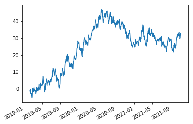

```python
import matplotlib.pyplot as plt
#Series绘图
ts=pd.Series(np.random.randn(1000),index=pd.date_range('2/9/2019 17:00',periods=1000))
ts=ts.cumsum()
ts.plot()
```

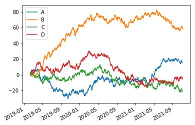

```python
#DataFrame绘制
df=pd.DataFrame(np.random.randn(1000,4),index=ts.index,columns=list('ABCD'))
df=df.cumsum()
df.plot()#直接plot则会把DataFrame当成多个Series绘制出每一个Series
plt.legend(loc='best')
```

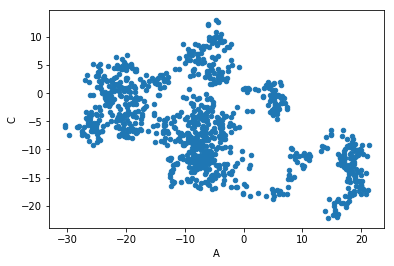

```python
df.plot.scatter('A','C')#还可以指定绘制的两个列分别作为x,y坐标
```

### I/O读写

对应各种格式的读写就是`read_格式`与`to_格式`：

```python
df=pd.read_csv('T0006CH1.CSV',header=None)
df=df[15:]
df.columns=['time','amp']
df.head()
```

|  | time | amp |
| --- | --- | --- |
| 15 | -1.08000e-05 | 2 |
| 16 | -1.07990e-05 | 4.47035e-08 |
| 17 | -1.07980e-05 | 4.47035e-08 |
| 18 | -1.07970e-05 | 4.47035e-08 |
| 19 | -1.07960e-05 | 2 |

这里有一个问题是读入的数据都是`str`类型而不是数值类型，无法进一步处理。可以用Series的`astype`函数将字符串类型转化为数值类型

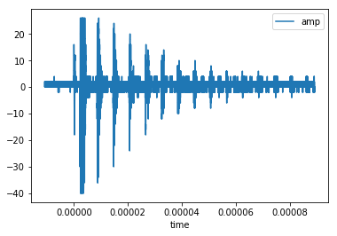

```python
df['time']=df['time'].astype(np.float64)
df['amp']=df['amp'].astype(np.float64)
df.plot('time','amp')
```

```python
df.index=list(range(1,len(df)+1))
df.head()
```

|  | time | amp |
| --- | --- | --- |
| 1 | -0.000011 | 2.000000e+00 |
| 2 | -0.000011 | 4.470350e-08 |
| 3 | -0.000011 | 4.470350e-08 |
| 4 | -0.000011 | 4.470350e-08 |
| 5 | -0.000011 | 2.000000e+00 |

```python
df.to_excel('test.xlsx',sheet_name='Sheet1',header=True)
```